# Number of walks

# 1 Description of DataSchema variable

The description of harmonised variable is the following:

- Short name: `n_walks`
- Variable label: `Number of walks`
- Variable description: `Number of walks in the last month (0.5 km or at least 10 min)`
- Domain: `Lifestyle and health behaviours`
- Value type: `continuous`
- Category missings:

| **Code** | **Category Label** |
| --- | --- |
| 991 | CAPI/interviewer error |
| 992 | Impute |
| 993 | Disable to measure |
| 994 | Not attempt/not done |
| 995 | Does not answer |
| 996 | Not applicable |
| 997 | Refuse |
| 998 | Do not know |
| 999 | Missing |

# 2 Data process

## 2.1 Cuba

### 2.1.1 Wave 1

#### 2.1.1.1 Study-specific variable description

| **Name** | `PWALKOFT` |
| --- | --- |
| **Label** | `how many walks of 0.5 kilometre in last month?` |
| **Table name** | `1066-Cuba-Baseline` |
| **Categories** | `continuous` |
| **Missings** | `NA` |
| **Description** |  |

PWALKOFT

| Sample size | Missing values |
| --- | --- |
| 2813 | 54 |

Summary

| Min. | 1st Qu. | Median | Mean | 3rd Qu. | Max. | NA’s |
| --- | --- | --- | --- | --- | --- | --- |
| 0 | 0 | 5 | 11.41 | 29 | 60 | 54 |

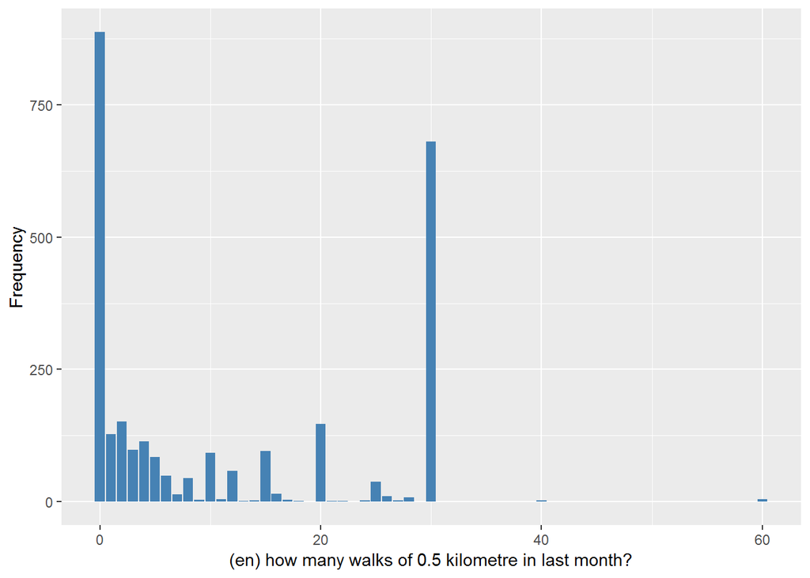

#### 2.1.1.2 Harmonisation algorithm

To compute the harmonize variable from the study-specific variable it has to be recoded as follows:

- `NA into 999`

```r
t1066_ds_cuba_w1 <- tibble(id = t1066_cuba_w1$id)
t1066_ds_cuba_w1$n_walks <- Recode(t1066_cuba_w1$PWALKOFT, "NA = '999' ")
t1066_ds_cuba_w1$n_walks <- labelled(t1066_ds_cuba_w1$n_walks, labels = c(Missing = 999,
    Do_not_know = 998, Refuse = 997, Not_applicable = 996, Does_not_answer = 995,
    Not_attempt_not_done = 994, Disable_to_measure = 993, Impute = 992, CAPI_interviewer_error = 991))
```

#### 2.1.1.3 Statistical description of the new harmonised variable

Number of walks

| Sample size | Missing values |
| --- | --- |
| 2813 | 54 |

Values

|  | No-missings | 991 | 992 | 993 | 994 | 995 | 996 | 997 | 998 | 999 | NA |
| --- | --- | --- | --- | --- | --- | --- | --- | --- | --- | --- | --- |
| Frequency | 2759.00 | 0 | 0 | 0 | 0 | 0 | 0 | 0 | 0 | 54.00 | 0 |
| Percentage | 98.08 | 0 | 0 | 0 | 0 | 0 | 0 | 0 | 0 | 1.92 | 0 |

Summary

| Min. | 1st Qu. | Median | Mean | 3rd Qu. | Max. |
| --- | --- | --- | --- | --- | --- |
| 0 | 0 | 5 | 11.41 | 29 | 60 |

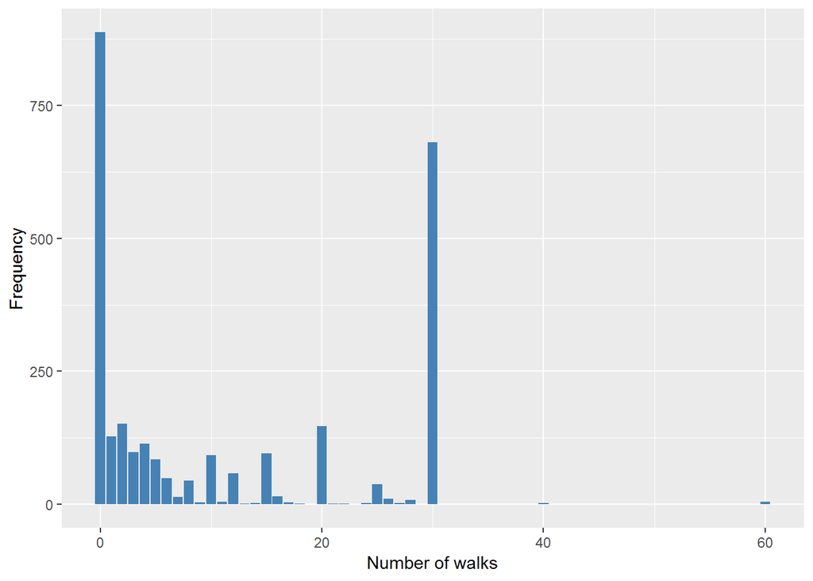

#### 2.1.1.4 Validation

|  | 0->0 | 1->1 | 2->2 | 3->3 | 4->4 | 5->5 | 6->6 | 7->7 | 8->8 | 9->9 | 10->10 | 11->11 | 12->12 | 13->13 | 14->14 | 15->15 | 16->16 | 17->17 | 18->18 | 20->20 | 21->21 | 22->22 | 23->23 | 24->24 | 25->25 | 26->26 | 27->27 | 28->28 | 30->30 | … |
| --- | --- | --- | --- | --- | --- | --- | --- | --- | --- | --- | --- | --- | --- | --- | --- | --- | --- | --- | --- | --- | --- | --- | --- | --- | --- | --- | --- | --- | --- | --- |
| BeforeH | 887 | 128 | 152 | 98 | 114 | 85 | 49 | 14 | 45 | 4 | 93 | 5 | 58 | 2 | 3 | 96 | 15 | 4 | 2 | 147 | 2 | 2 | 1 | 3 | 38 | 11 | 3 | 8 | 680 | … |
| AfterH | 887 | 128 | 152 | 98 | 114 | 85 | 49 | 14 | 45 | 4 | 93 | 5 | 58 | 2 | 3 | 96 | 15 | 4 | 2 | 147 | 2 | 2 | 1 | 3 | 38 | 11 | 3 | 8 | 680 | … |

### 2.1.2 Wave 2

#### 2.1.2.1 Study-specific variable description

| **Name** | `f_PWALKOFT` |
| --- | --- |
| **Label** | `how many walks of 0.5 kilometre in last month?` |
| **Table name** | `1066-Cuba-Followup` |
| **Categories** | `continuous` |
| **Missings** | `NA` |
| **Description** |  |

f_PWALKOFT

| Sample size | Missing values |
| --- | --- |
| 2007 | 757 |

Summary

| Min. | 1st Qu. | Median | Mean | 3rd Qu. | Max. | NA’s |
| --- | --- | --- | --- | --- | --- | --- |
| 0 | 2 | 8 | 13.01 | 30 | 80 | 757 |

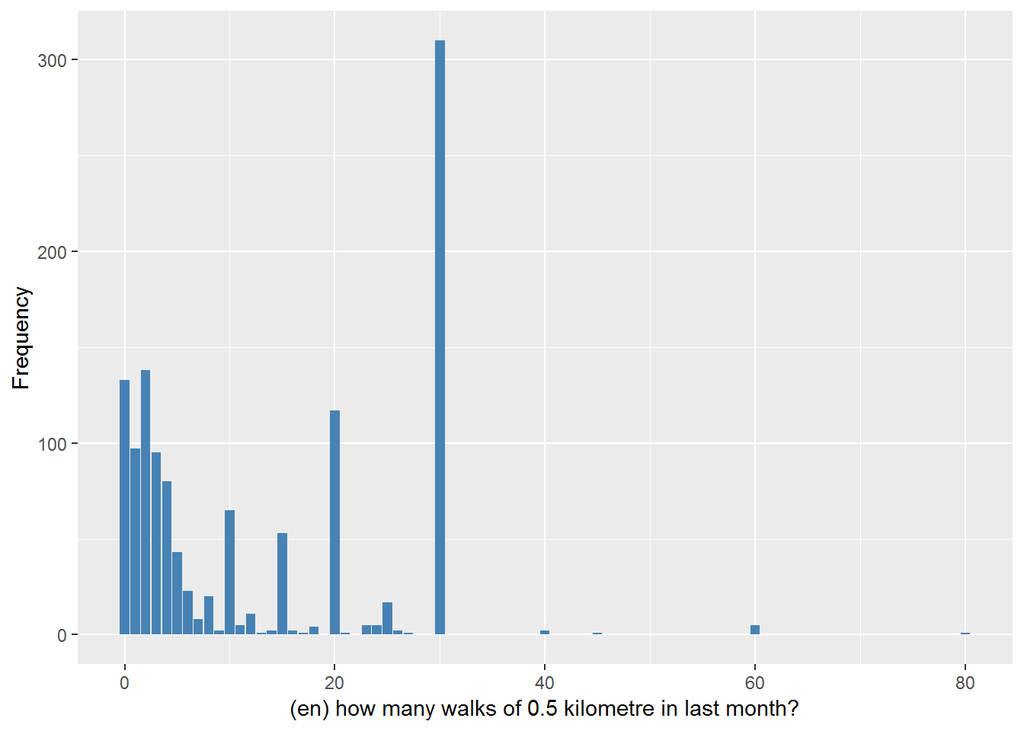

#### 2.1.2.2 Harmonisation algorithm

To compute the harmonize variable from the study-specific variable it has to be recoded as follows:

- `NA into 999`

```r
t1066_ds_cuba_w2 <- tibble(id = t1066_cuba_w2$id)
t1066_ds_cuba_w2$n_walks <- Recode(t1066_cuba_w2$f_PWALKOFT, "NA = '999' ")
t1066_ds_cuba_w2$n_walks <- labelled(t1066_ds_cuba_w2$n_walks, labels = c(Missing = 999,
    Do_not_know = 998, Refuse = 997, Not_applicable = 996, Does_not_answer = 995,
    Not_attempt_not_done = 994, Disable_to_measure = 993, Impute = 992, CAPI_interviewer_error = 991))
```

#### 2.1.2.3 Statistical description of the new harmonised variable

Number of walks

| Sample size | Missing values |
| --- | --- |
| 2007 | 757 |

Values

|  | No-missings | 991 | 992 | 993 | 994 | 995 | 996 | 997 | 998 | 999 | NA |
| --- | --- | --- | --- | --- | --- | --- | --- | --- | --- | --- | --- |
| Frequency | 1250.00 | 0 | 0 | 0 | 0 | 0 | 0 | 0 | 0 | 757.00 | 0 |
| Percentage | 62.28 | 0 | 0 | 0 | 0 | 0 | 0 | 0 | 0 | 37.72 | 0 |

Summary

| Min. | 1st Qu. | Median | Mean | 3rd Qu. | Max. |
| --- | --- | --- | --- | --- | --- |
| 0 | 2 | 8 | 13.01 | 30 | 80 |

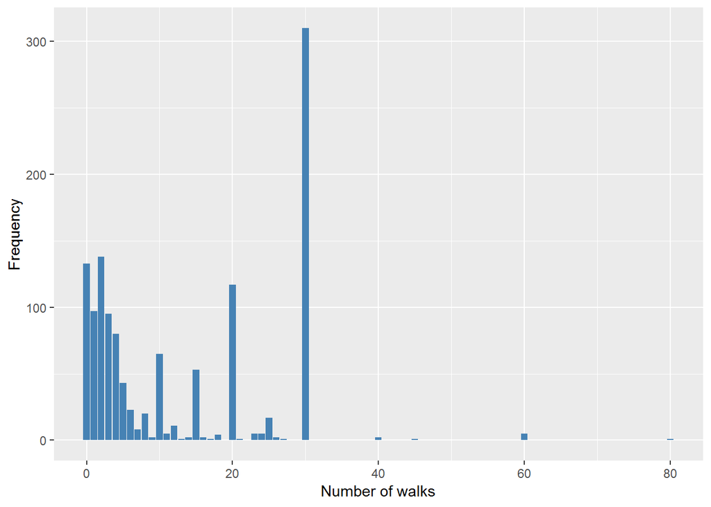

#### 2.1.2.4 Validation

|  | 0->0 | 1->1 | 2->2 | 3->3 | 4->4 | 5->5 | 6->6 | 7->7 | 8->8 | 9->9 | 10->10 | 11->11 | 12->12 | 13->13 | 14->14 | 15->15 | 16->16 | 17->17 | 18->18 | 20->20 | 21->21 | 23->23 | 24->24 | 25->25 | 26->26 | 27->27 | 30->30 | 40->40 | 45->45 | … |
| --- | --- | --- | --- | --- | --- | --- | --- | --- | --- | --- | --- | --- | --- | --- | --- | --- | --- | --- | --- | --- | --- | --- | --- | --- | --- | --- | --- | --- | --- | --- |
| BeforeH | 133 | 97 | 138 | 95 | 80 | 43 | 23 | 8 | 20 | 2 | 65 | 5 | 11 | 1 | 2 | 53 | 2 | 1 | 4 | 117 | 1 | 5 | 5 | 17 | 2 | 1 | 310 | 2 | 1 | … |
| AfterH | 133 | 97 | 138 | 95 | 80 | 43 | 23 | 8 | 20 | 2 | 65 | 5 | 11 | 1 | 2 | 53 | 2 | 1 | 4 | 117 | 1 | 5 | 5 | 17 | 2 | 1 | 310 | 2 | 1 | … |

## 2.2 India

### 2.2.1 Wave 1

#### 2.2.1.1 Study-specific variable description

| **Name** | `PWALKOFT` |
| --- | --- |
| **Label** | `how many walks of 0.5 kilometre in last month?` |
| **Table name** | `1066-India-Baseline` |
| **Categories** | `continuous` |
| **Missings** | `NA` |
| **Description** |  |

PWALKOFT

| Sample size | Missing values |
| --- | --- |
| 2004 | 55 |

Summary

| Min. | 1st Qu. | Median | Mean | 3rd Qu. | Max. | NA’s |
| --- | --- | --- | --- | --- | --- | --- |
| 0 | 1 | 2 | 4.788 | 6 | 40 | 55 |

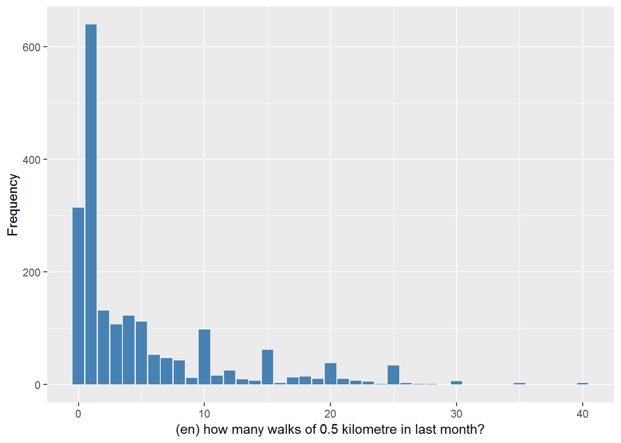

#### 2.2.1.2 Harmonisation algorithm

To compute the harmonize variable from the study-specific variable it has to be recoded as follows:

- `NA into 999`

```r
t1066_ds_india_w1 <- tibble(id = t1066_india_w1$id)
t1066_ds_india_w1$n_walks <- Recode(t1066_india_w1$PWALKOFT, "NA = '999' ")
t1066_ds_india_w1$n_walks <- labelled(t1066_ds_india_w1$n_walks, labels = c(Missing = 999,
    Do_not_know = 998, Refuse = 997, Not_applicable = 996, Does_not_answer = 995,
    Not_attempt_not_done = 994, Disable_to_measure = 993, Impute = 992, CAPI_interviewer_error = 991))
```

#### 2.2.1.3 Statistical description of the new harmonised variable

Number of walks

| Sample size | Missing values |
| --- | --- |
| 2004 | 55 |

Values

|  | No-missings | 991 | 992 | 993 | 994 | 995 | 996 | 997 | 998 | 999 | NA |
| --- | --- | --- | --- | --- | --- | --- | --- | --- | --- | --- | --- |
| Frequency | 1949.00 | 0 | 0 | 0 | 0 | 0 | 0 | 0 | 0 | 55.00 | 0 |
| Percentage | 97.26 | 0 | 0 | 0 | 0 | 0 | 0 | 0 | 0 | 2.74 | 0 |

Summary

| Min. | 1st Qu. | Median | Mean | 3rd Qu. | Max. |
| --- | --- | --- | --- | --- | --- |
| 0 | 1 | 2 | 4.788 | 6 | 40 |

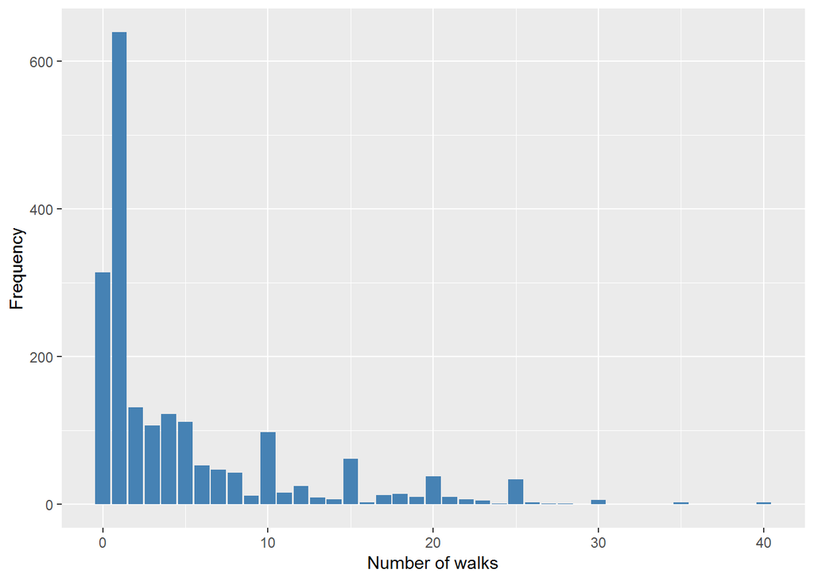

#### 2.2.1.4 Validation

|  | 0->0 | 1->1 | 2->2 | 3->3 | 4->4 | 5->5 | 6->6 | 7->7 | 8->8 | 9->9 | 10->10 | 11->11 | 12->12 | 13->13 | 14->14 | 15->15 | 16->16 | 17->17 | 18->18 | 19->19 | 20->20 | 21->21 | 22->22 | 23->23 | 24->24 | 25->25 | 26->26 | 27->27 | 28->28 | … |
| --- | --- | --- | --- | --- | --- | --- | --- | --- | --- | --- | --- | --- | --- | --- | --- | --- | --- | --- | --- | --- | --- | --- | --- | --- | --- | --- | --- | --- | --- | --- |
| BeforeH | 314 | 639 | 131 | 107 | 122 | 112 | 53 | 47 | 43 | 12 | 98 | 16 | 25 | 9 | 7 | 62 | 3 | 13 | 14 | 10 | 38 | 10 | 7 | 5 | 1 | 34 | 3 | 1 | 1 | … |
| AfterH | 314 | 639 | 131 | 107 | 122 | 112 | 53 | 47 | 43 | 12 | 98 | 16 | 25 | 9 | 7 | 62 | 3 | 13 | 14 | 10 | 38 | 10 | 7 | 5 | 1 | 34 | 3 | 1 | 1 | … |

## 2.3 Urban China

### 2.3.1 Wave 1

#### 2.3.1.1 Study-specific variable description

| **Name** | `PWALKOFT` |
| --- | --- |
| **Label** | `how many walks of 0.5 kilometre in last month?` |
| **Table name** | `1066-UrbanChina-Baseline` |
| **Categories** | `continuous` |
| **Missings** | `NA` |
| **Description** |  |

PWALKOFT

| Sample size | Missing values |
| --- | --- |
| 1160 | 17 |

Summary

| Min. | 1st Qu. | Median | Mean | 3rd Qu. | Max. | NA’s |
| --- | --- | --- | --- | --- | --- | --- |
| 0 | 10 | 25 | 19.68 | 30 | 31 | 17 |

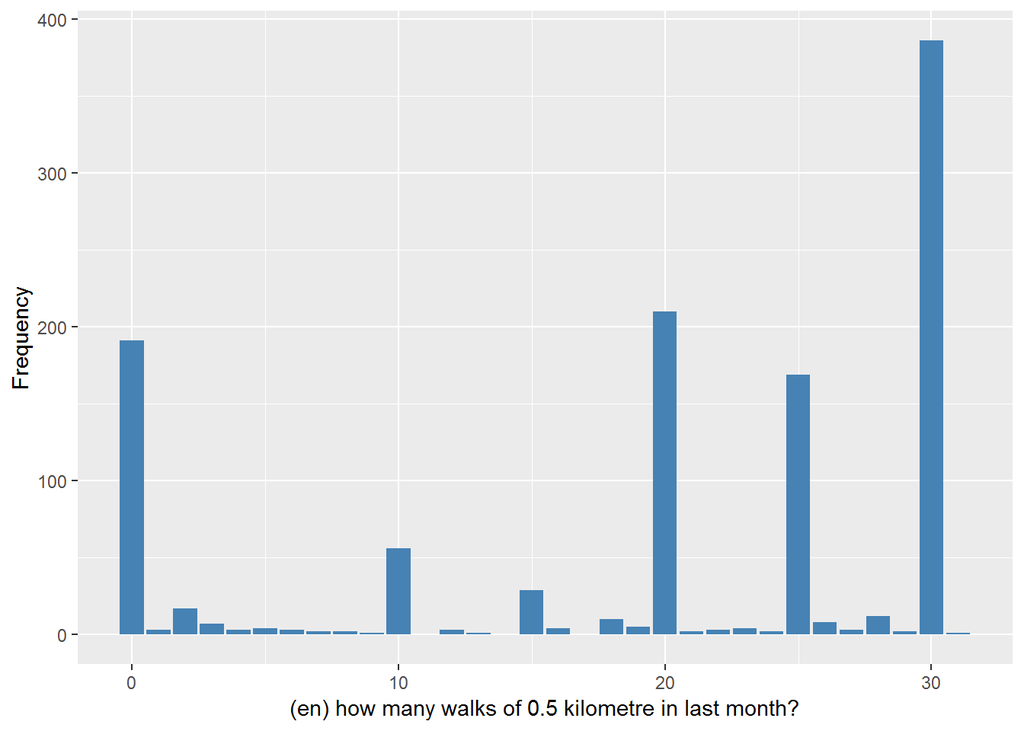

#### 2.3.1.2 Harmonisation algorithm

To compute the harmonize variable from the study-specific variable it has to be recoded as follows:

- `NA into 999`

```r
t1066_ds_UCh_w1 <- tibble(id = t1066_UCh_w1$id)
t1066_ds_UCh_w1$n_walks <- Recode(t1066_UCh_w1$PWALKOFT, "NA = '999' ")
t1066_ds_UCh_w1$n_walks <- labelled(t1066_ds_UCh_w1$n_walks, labels = c(Missing = 999,
    Do_not_know = 998, Refuse = 997, Not_applicable = 996, Does_not_answer = 995,
    Not_attempt_not_done = 994, Disable_to_measure = 993, Impute = 992, CAPI_interviewer_error = 991))
```

#### 2.3.1.3 Statistical description of the new harmonised variable

Number of walks

| Sample size | Missing values |
| --- | --- |
| 1160 | 17 |

Values

|  | No-missings | 991 | 992 | 993 | 994 | 995 | 996 | 997 | 998 | 999 | NA |
| --- | --- | --- | --- | --- | --- | --- | --- | --- | --- | --- | --- |
| Frequency | 1143.00 | 0 | 0 | 0 | 0 | 0 | 0 | 0 | 0 | 17.00 | 0 |
| Percentage | 98.53 | 0 | 0 | 0 | 0 | 0 | 0 | 0 | 0 | 1.47 | 0 |

Summary

| Min. | 1st Qu. | Median | Mean | 3rd Qu. | Max. |
| --- | --- | --- | --- | --- | --- |
| 0 | 10 | 25 | 19.68 | 30 | 31 |

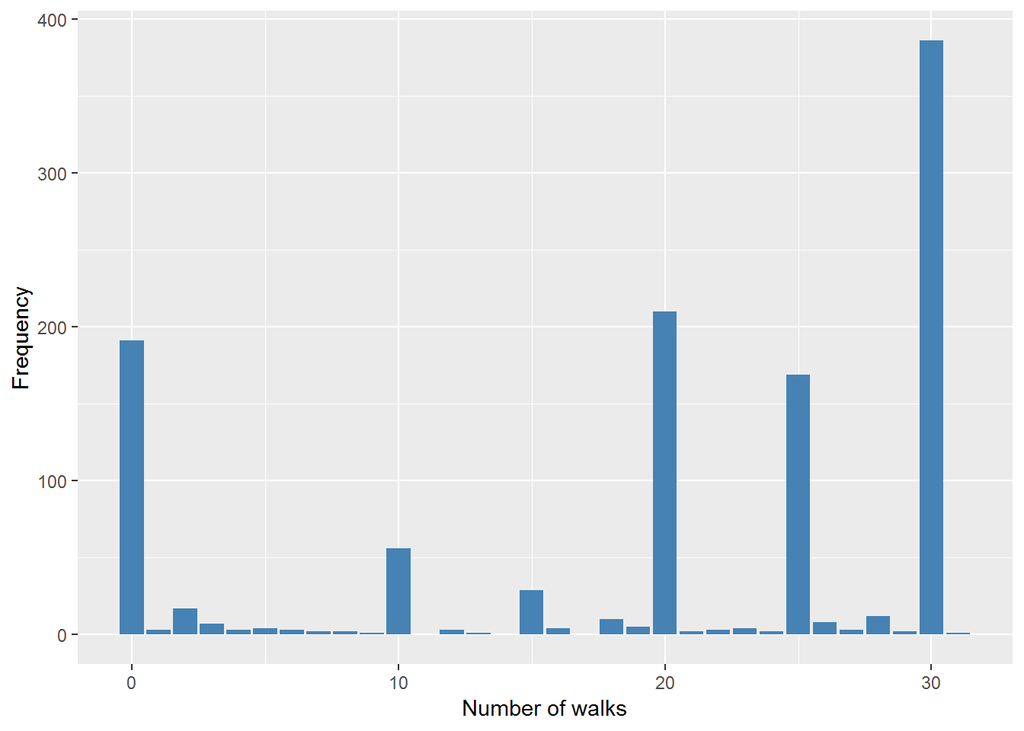

#### 2.3.1.4 Validation

|  | 0->0 | 1->1 | 2->2 | 3->3 | 4->4 | 5->5 | 6->6 | 7->7 | 8->8 | 9->9 | 10->10 | 12->12 | 13->13 | 15->15 | 16->16 | 18->18 | 19->19 | 20->20 | 21->21 | 22->22 | 23->23 | 24->24 | 25->25 | 26->26 | 27->27 | 28->28 | 29->29 | 30->30 | 31->31 | … |
| --- | --- | --- | --- | --- | --- | --- | --- | --- | --- | --- | --- | --- | --- | --- | --- | --- | --- | --- | --- | --- | --- | --- | --- | --- | --- | --- | --- | --- | --- | --- |
| BeforeH | 191 | 3 | 17 | 7 | 3 | 4 | 3 | 2 | 2 | 1 | 56 | 3 | 1 | 29 | 4 | 10 | 5 | 210 | 2 | 3 | 4 | 2 | 169 | 8 | 3 | 12 | 2 | 386 | 1 | … |
| AfterH | 191 | 3 | 17 | 7 | 3 | 4 | 3 | 2 | 2 | 1 | 56 | 3 | 1 | 29 | 4 | 10 | 5 | 210 | 2 | 3 | 4 | 2 | 169 | 8 | 3 | 12 | 2 | 386 | 1 | … |

### 2.3.2 Wave 2

#### 2.3.2.1 Study-specific variable description

| **Name** | `f_PWALKOFT` |
| --- | --- |
| **Label** | `how many walks of 0.5 kilometre in last month?` |
| **Table name** | `1066-UrbanChina-Followup` |
| **Categories** | `continuous` |
| **Missings** | `NA` |
| **Description** |  |

f_PWALKOFT

| Sample size | Missing values |
| --- | --- |
| 741 | 141 |

Summary

| Min. | 1st Qu. | Median | Mean | 3rd Qu. | Max. | NA’s |
| --- | --- | --- | --- | --- | --- | --- |
| 0 | 15 | 20 | 20.19 | 30 | 40 | 141 |

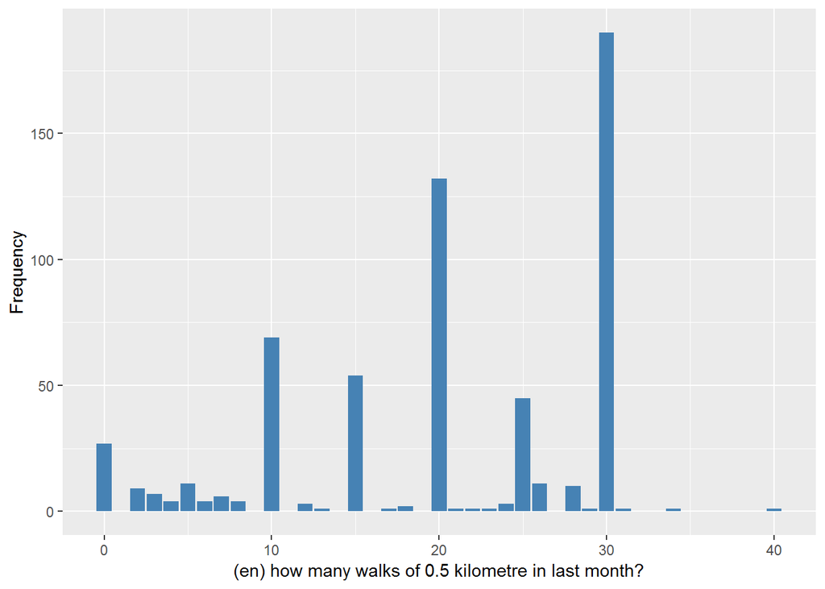

#### 2.3.2.2 Harmonisation algorithm

To compute the harmonize variable from the study-specific variable it has to be recoded as follows

- `NA into 999`

```r
t1066_ds_UCh_w2 <- tibble(id = t1066_UCh_w2$id)
t1066_ds_UCh_w2$n_walks <- Recode(t1066_UCh_w2$f_PWALKOFT, "NA = '999' ")
t1066_ds_UCh_w2$n_walks <- labelled(t1066_ds_UCh_w2$n_walks, labels = c(Missing = 999,
    Do_not_know = 998, Refuse = 997, Not_applicable = 996, Does_not_answer = 995,
    Not_attempt_not_done = 994, Disable_to_measure = 993, Impute = 992, CAPI_interviewer_error = 991))
```

#### 2.3.2.3 Statistical description of the new harmonised variable

Number of walks

| Sample size | Missing values |
| --- | --- |
| 741 | 141 |

Values

|  | No-missings | 991 | 992 | 993 | 994 | 995 | 996 | 997 | 998 | 999 | NA |
| --- | --- | --- | --- | --- | --- | --- | --- | --- | --- | --- | --- |
| Frequency | 600.00 | 0 | 0 | 0 | 0 | 0 | 0 | 0 | 0 | 141.00 | 0 |
| Percentage | 80.97 | 0 | 0 | 0 | 0 | 0 | 0 | 0 | 0 | 19.03 | 0 |

Summary

| Min. | 1st Qu. | Median | Mean | 3rd Qu. | Max. |
| --- | --- | --- | --- | --- | --- |
| 0 | 15 | 20 | 20.19 | 30 | 40 |

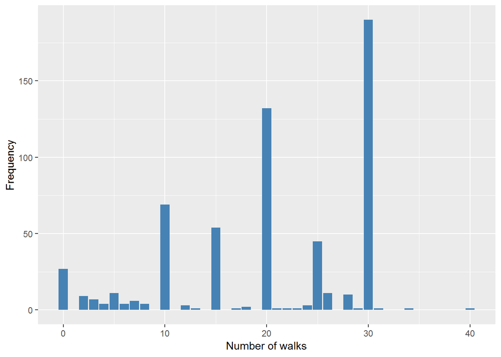

#### 2.3.2.4 Validation

|  | 0->0 | 2->2 | 3->3 | 4->4 | 5->5 | 6->6 | 7->7 | 8->8 | 10->10 | 12->12 | 13->13 | 15->15 | 17->17 | 18->18 | 20->20 | 21->21 | 22->22 | 23->23 | 24->24 | 25->25 | 26->26 | 28->28 | 29->29 | 30->30 | 31->31 | 34->34 | 40->40 | NA->999 |
| --- | --- | --- | --- | --- | --- | --- | --- | --- | --- | --- | --- | --- | --- | --- | --- | --- | --- | --- | --- | --- | --- | --- | --- | --- | --- | --- | --- | --- |
| BeforeH | 27 | 9 | 7 | 4 | 11 | 4 | 6 | 4 | 69 | 3 | 1 | 54 | 1 | 2 | 132 | 1 | 1 | 1 | 3 | 45 | 11 | 10 | 1 | 190 | 1 | 1 | 1 | 141 |
| AfterH | 27 | 9 | 7 | 4 | 11 | 4 | 6 | 4 | 69 | 3 | 1 | 54 | 1 | 2 | 132 | 1 | 1 | 1 | 3 | 45 | 11 | 10 | 1 | 190 | 1 | 1 | 1 | 141 |

## 2.4 Rural China

### 2.4.1 Wave 1

#### 2.4.1.1 Study-specific variable description

| **Name** | `PWALKOFT` |
| --- | --- |
| **Label** | `how many walks of 0.5 kilometre in last month?` |
| **Table name** | `1066-RuralChina-Baseline` |
| **Categories** | `continuous` |
| **Missings** | `NA` |
| **Description** |  |

PWALKOFT

| Sample size | Missing values |
| --- | --- |
| 1002 | 9 |

Summary

| Min. | 1st Qu. | Median | Mean | 3rd Qu. | Max. | NA’s |
| --- | --- | --- | --- | --- | --- | --- |
| 0 | 0 | 5 | 9.281 | 20 | 30 | 9 |

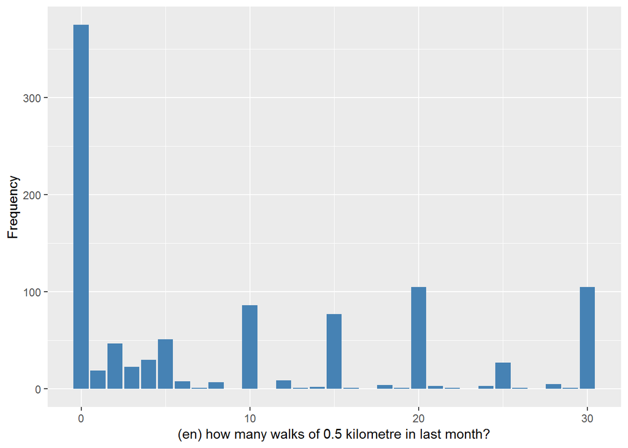

#### 2.4.1.2 Harmonisation algorithm

To compute the harmonize variable from the study-specific variable it has to be recoded as follows:

- `NA into 999`

```r
t1066_ds_RCh_w1 <- tibble(id = t1066_RCh_w1$id)
t1066_ds_RCh_w1$n_walks <- Recode(t1066_RCh_w1$PWALKOFT, "NA = '999' ")
t1066_ds_RCh_w1$n_walks <- labelled(t1066_ds_RCh_w1$n_walks, labels = c(Missing = 999,
    Do_not_know = 998, Refuse = 997, Not_applicable = 996, Does_not_answer = 995,
    Not_attempt_not_done = 994, Disable_to_measure = 993, Impute = 992, CAPI_interviewer_error = 991))
```

#### 2.4.1.3 Statistical description of the new harmonised variable

Number of walks

| Sample size | Missing values |
| --- | --- |
| 1002 | 9 |

Values

|  | No-missings | 991 | 992 | 993 | 994 | 995 | 996 | 997 | 998 | 999 | NA |
| --- | --- | --- | --- | --- | --- | --- | --- | --- | --- | --- | --- |
| Frequency | 993.0 | 0 | 0 | 0 | 0 | 0 | 0 | 0 | 0 | 9.0 | 0 |
| Percentage | 99.1 | 0 | 0 | 0 | 0 | 0 | 0 | 0 | 0 | 0.9 | 0 |

Summary

| Min. | 1st Qu. | Median | Mean | 3rd Qu. | Max. |
| --- | --- | --- | --- | --- | --- |
| 0 | 0 | 5 | 9.281 | 20 | 30 |

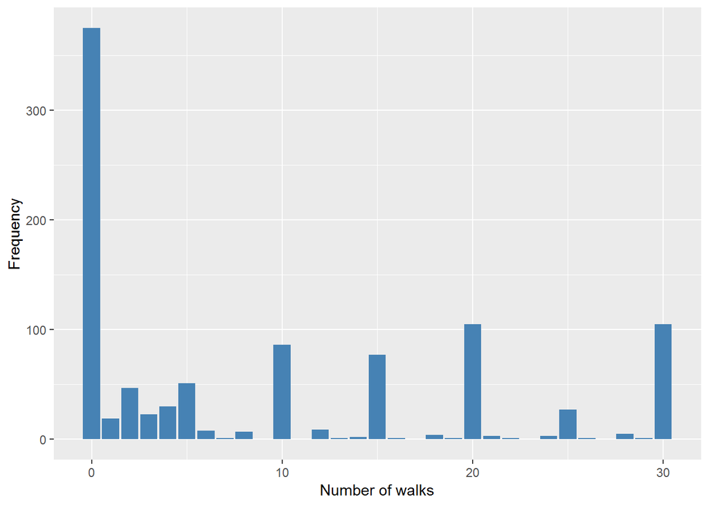

#### 2.4.1.4 Validation

|  | 0->0 | 1->1 | 2->2 | 3->3 | 4->4 | 5->5 | 6->6 | 7->7 | 8->8 | 10->10 | 12->12 | 13->13 | 14->14 | 15->15 | 16->16 | 18->18 | 19->19 | 20->20 | 21->21 | 22->22 | 24->24 | 25->25 | 26->26 | 28->28 | 29->29 | 30->30 | NA->999 |
| --- | --- | --- | --- | --- | --- | --- | --- | --- | --- | --- | --- | --- | --- | --- | --- | --- | --- | --- | --- | --- | --- | --- | --- | --- | --- | --- | --- |
| BeforeH | 375 | 19 | 47 | 23 | 30 | 51 | 8 | 1 | 7 | 86 | 9 | 1 | 2 | 77 | 1 | 4 | 1 | 105 | 3 | 1 | 3 | 27 | 1 | 5 | 1 | 105 | 9 |
| AfterH | 375 | 19 | 47 | 23 | 30 | 51 | 8 | 1 | 7 | 86 | 9 | 1 | 2 | 77 | 1 | 4 | 1 | 105 | 3 | 1 | 3 | 27 | 1 | 5 | 1 | 105 | 9 |

### 2.4.2 Wave 2

#### 2.4.2.1 Study-specific variable description

| **Name** | `f_PWALKOFT` |
| --- | --- |
| **Label** | `how many walks of 0.5 kilometre in last month?` |
| **Table name** | `1066-RuralChina-Followup` |
| **Categories** | `continuous` |
| **Missings** | `NA` |
| **Description** |  |

f_PWALKOFT

| Sample size | Missing values |
| --- | --- |
| 711 | 118 |

Summary

| Min. | 1st Qu. | Median | Mean | 3rd Qu. | Max. | NA’s |
| --- | --- | --- | --- | --- | --- | --- |
| 0 | 5 | 15 | 14.74 | 23 | 30 | 118 |

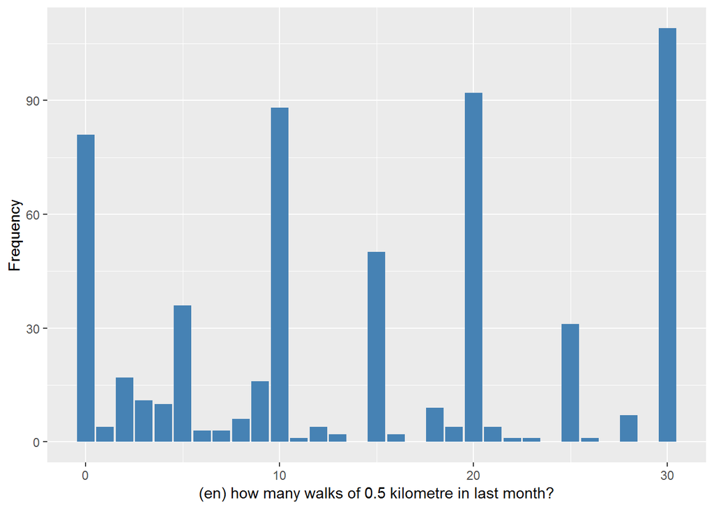

#### 2.4.2.2 Harmonisation algorithm

To compute the harmonize variable from the study-specific variable it has to be recoded as follows:

- `NA into 999`

```r
t1066_ds_RCh_w2 <- tibble(id = t1066_RCh_w2$id)
t1066_ds_RCh_w2$n_walks <- Recode(t1066_RCh_w2$f_PWALKOFT, "NA = '999' ")
t1066_ds_RCh_w2$n_walks <- labelled(t1066_ds_RCh_w2$n_walks, labels = c(Missing = 999,
    Do_not_know = 998, Refuse = 997, Not_applicable = 996, Does_not_answer = 995,
    Not_attempt_not_done = 994, Disable_to_measure = 993, Impute = 992, CAPI_interviewer_error = 991))
```

#### 2.4.2.3 Statistical description of the new harmonised variable

Number of walks

| Sample size | Missing values |
| --- | --- |
| 711 | 118 |

Values

|  | No-missings | 991 | 992 | 993 | 994 | 995 | 996 | 997 | 998 | 999 | NA |
| --- | --- | --- | --- | --- | --- | --- | --- | --- | --- | --- | --- |
| Frequency | 593.0 | 0 | 0 | 0 | 0 | 0 | 0 | 0 | 0 | 118.0 | 0 |
| Percentage | 83.4 | 0 | 0 | 0 | 0 | 0 | 0 | 0 | 0 | 16.6 | 0 |

Summary

| Min. | 1st Qu. | Median | Mean | 3rd Qu. | Max. |
| --- | --- | --- | --- | --- | --- |
| 0 | 5 | 15 | 14.74 | 23 | 30 |

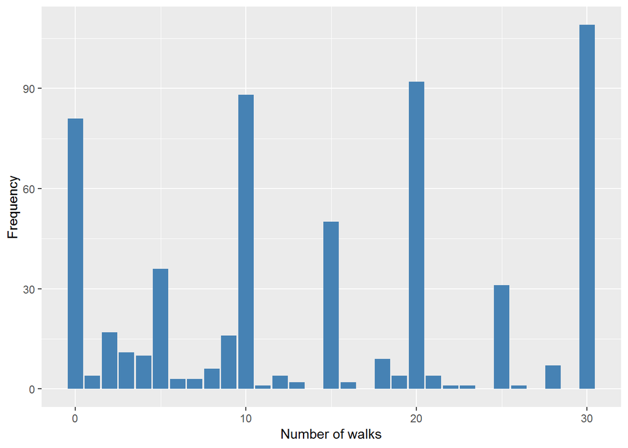

#### 2.4.2.4 Validation

|  | 0->0 | 1->1 | 2->2 | 3->3 | 4->4 | 5->5 | 6->6 | 7->7 | 8->8 | 9->9 | 10->10 | 11->11 | 12->12 | 13->13 | 15->15 | 16->16 | 18->18 | 19->19 | 20->20 | 21->21 | 22->22 | 23->23 | 25->25 | 26->26 | 28->28 | 30->30 | NA->999 |
| --- | --- | --- | --- | --- | --- | --- | --- | --- | --- | --- | --- | --- | --- | --- | --- | --- | --- | --- | --- | --- | --- | --- | --- | --- | --- | --- | --- |
| BeforeH | 81 | 4 | 17 | 11 | 10 | 36 | 3 | 3 | 6 | 16 | 88 | 1 | 4 | 2 | 50 | 2 | 9 | 4 | 92 | 4 | 1 | 1 | 31 | 1 | 7 | 109 | 118 |
| AfterH | 81 | 4 | 17 | 11 | 10 | 36 | 3 | 3 | 6 | 16 | 88 | 1 | 4 | 2 | 50 | 2 | 9 | 4 | 92 | 4 | 1 | 1 | 31 | 1 | 7 | 109 | 118 |

## 2.5 Dominican Republic

### 2.5.1 Wave 1

#### 2.5.1.1 Study-specific variable description

| **Name** | `PWALKOFT` |
| --- | --- |
| **Label** | `how many walks of 0.5 kilometre in last month?` |
| **Table name** | `1066-DominicanRepublic-Baseline` |
| **Categories** | `continuous` |
| **Missings** | `NA` |
| **Description** |  |

PWALKOFT

| Sample size | Missing values |
| --- | --- |
| 2011 | 377 |

Summary

| Min. | 1st Qu. | Median | Mean | 3rd Qu. | Max. | NA’s |
| --- | --- | --- | --- | --- | --- | --- |
| 0 | 1 | 6 | 13.2 | 30 | 40 | 377 |

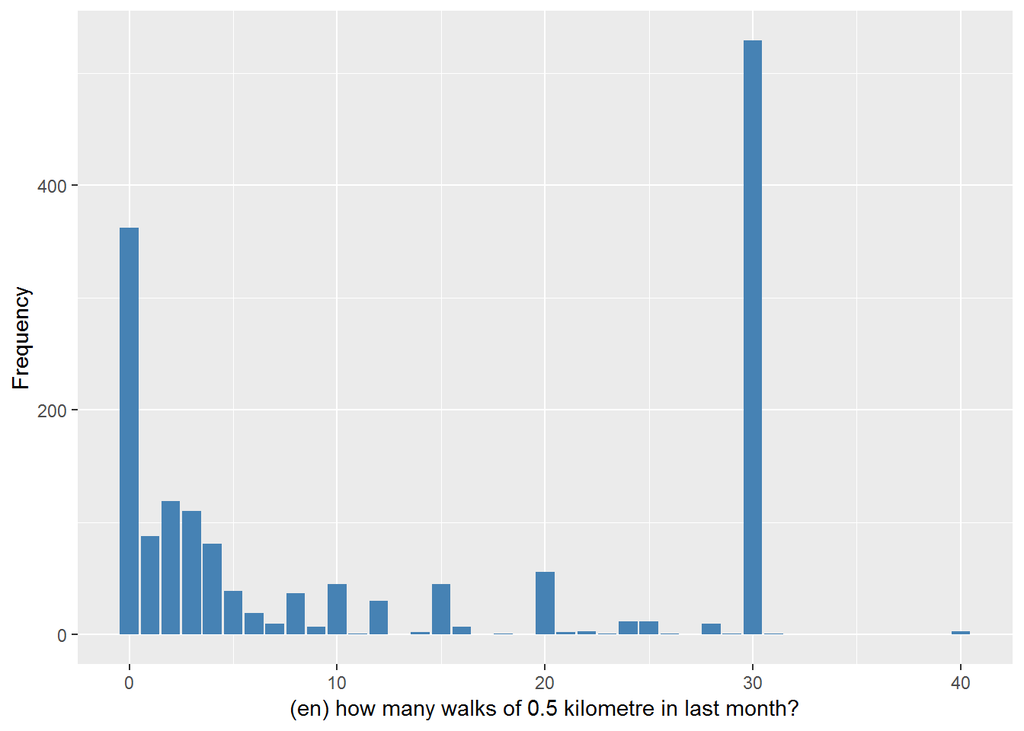

#### 2.5.1.2 Harmonisation algorithm

To compute the harmonize variable from the study-specific variable it has to be recoded as follows:

- `NA into 999`

```r
t1066_ds_DR_w1 <- tibble(id = t1066_DR_w1$id)
t1066_ds_DR_w1$n_walks <- Recode(t1066_DR_w1$PWALKOFT, "NA = '999' ")
t1066_ds_DR_w1$n_walks <- labelled(t1066_ds_DR_w1$n_walks, labels = c(Missing = 999,
    Do_not_know = 998, Refuse = 997, Not_applicable = 996, Does_not_answer = 995,
    Not_attempt_not_done = 994, Disable_to_measure = 993, Impute = 992, CAPI_interviewer_error = 991))
```

#### 2.5.1.3 Statistical description of the new harmonised variable

Number of walks

| Sample size | Missing values |
| --- | --- |
| 2011 | 377 |

Values

|  | No-missings | 991 | 992 | 993 | 994 | 995 | 996 | 997 | 998 | 999 | NA |
| --- | --- | --- | --- | --- | --- | --- | --- | --- | --- | --- | --- |
| Frequency | 1634.00 | 0 | 0 | 0 | 0 | 0 | 0 | 0 | 0 | 377.00 | 0 |
| Percentage | 81.25 | 0 | 0 | 0 | 0 | 0 | 0 | 0 | 0 | 18.75 | 0 |

Summary

| Min. | 1st Qu. | Median | Mean | 3rd Qu. | Max. |
| --- | --- | --- | --- | --- | --- |
| 0 | 1 | 6 | 13.2 | 30 | 40 |

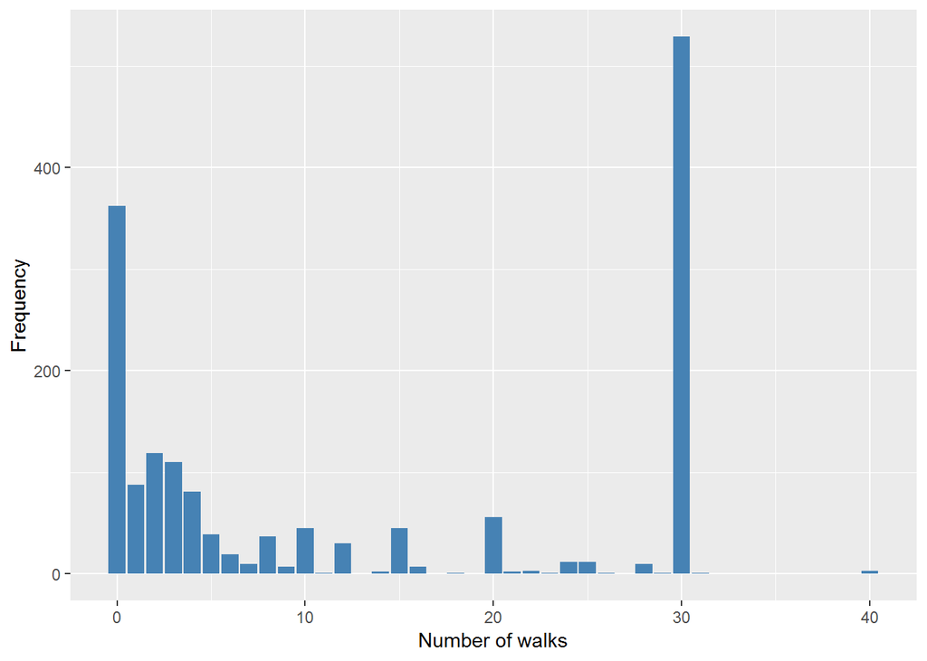

#### 2.5.1.4 Validation

|  | 0->0 | 1->1 | 2->2 | 3->3 | 4->4 | 5->5 | 6->6 | 7->7 | 8->8 | 9->9 | 10->10 | 11->11 | 12->12 | 14->14 | 15->15 | 16->16 | 18->18 | 20->20 | 21->21 | 22->22 | 23->23 | 24->24 | 25->25 | 26->26 | 28->28 | 29->29 | 30->30 | 31->31 | 40->40 | … |
| --- | --- | --- | --- | --- | --- | --- | --- | --- | --- | --- | --- | --- | --- | --- | --- | --- | --- | --- | --- | --- | --- | --- | --- | --- | --- | --- | --- | --- | --- | --- |
| BeforeH | 362 | 88 | 119 | 110 | 81 | 39 | 19 | 10 | 37 | 7 | 45 | 1 | 30 | 2 | 45 | 7 | 1 | 56 | 2 | 3 | 1 | 12 | 12 | 1 | 10 | 1 | 529 | 1 | 3 | … |
| AfterH | 362 | 88 | 119 | 110 | 81 | 39 | 19 | 10 | 37 | 7 | 45 | 1 | 30 | 2 | 45 | 7 | 1 | 56 | 2 | 3 | 1 | 12 | 12 | 1 | 10 | 1 | 529 | 1 | 3 | … |

### 2.5.2 Wave 2

#### 2.5.2.1 Study-specific variable description

| **Name** | `f_PWALKOFT` |
| --- | --- |
| **Label** | `how many walks of 0.5 kilometre in last month?` |
| **Table name** | `1066-DominicanRepublic-Followup` |
| **Categories** | `continuous` |
| **Missings** | `NA` |
| **Description** |  |

f_PWALKOFT

| Sample size | Missing values |
| --- | --- |
| 1197 | 561 |

Summary

| Min. | 1st Qu. | Median | Mean | 3rd Qu. | Max. | NA’s |
| --- | --- | --- | --- | --- | --- | --- |
| 0 | 3 | 8 | 13.06 | 28 | 40 | 561 |

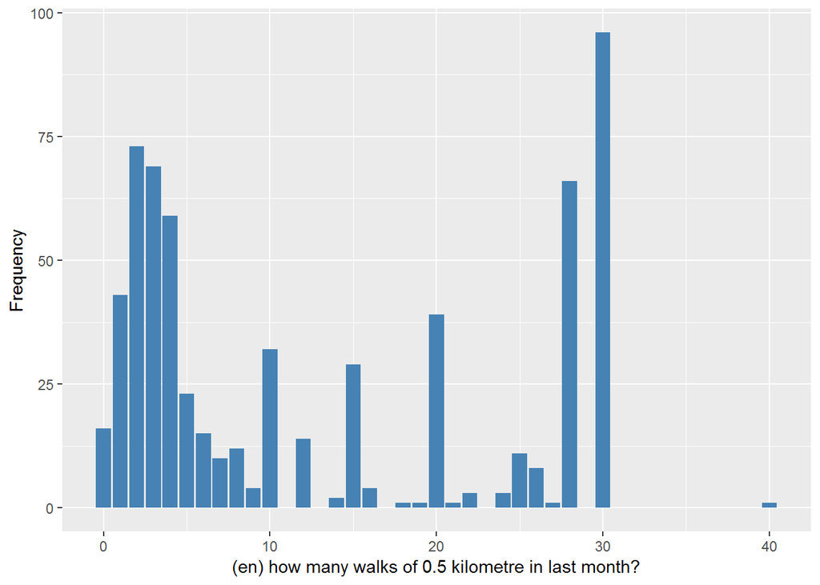

#### 2.5.2.2 Harmonisation algorithm

To compute the harmonize variable from the study-specific variable it has to be recoded as follows:

- `NA into 999`

```r
t1066_ds_DR_w2 <- tibble(id = t1066_DR_w2$id)
t1066_ds_DR_w2$n_walks <- Recode(t1066_DR_w2$f_PWALKOFT, "NA = '999' ")
t1066_ds_DR_w2$n_walks <- labelled(t1066_ds_DR_w2$n_walks, labels = c(Missing = 999,
    Do_not_know = 998, Refuse = 997, Not_applicable = 996, Does_not_answer = 995,
    Not_attempt_not_done = 994, Disable_to_measure = 993, Impute = 992, CAPI_interviewer_error = 991))
```

#### 2.5.2.3 Statistical description of the new harmonised variable

Number of walks

| Sample size | Missing values |
| --- | --- |
| 1197 | 561 |

Values

|  | No-missings | 991 | 992 | 993 | 994 | 995 | 996 | 997 | 998 | 999 | NA |
| --- | --- | --- | --- | --- | --- | --- | --- | --- | --- | --- | --- |
| Frequency | 636.00 | 0 | 0 | 0 | 0 | 0 | 0 | 0 | 0 | 561.00 | 0 |
| Percentage | 53.13 | 0 | 0 | 0 | 0 | 0 | 0 | 0 | 0 | 46.87 | 0 |

Summary

| Min. | 1st Qu. | Median | Mean | 3rd Qu. | Max. |
| --- | --- | --- | --- | --- | --- |
| 0 | 3 | 8 | 13.06 | 28 | 40 |

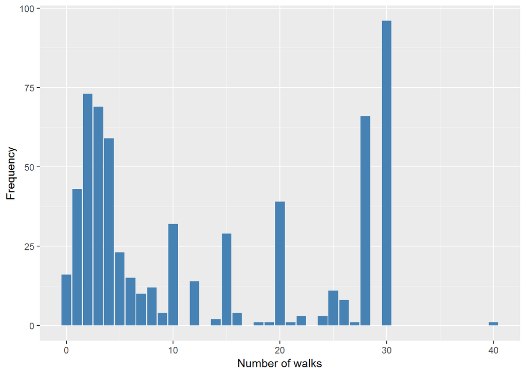

#### 2.5.2.4 Validation

|  | 0->0 | 1->1 | 2->2 | 3->3 | 4->4 | 5->5 | 6->6 | 7->7 | 8->8 | 9->9 | 10->10 | 12->12 | 14->14 | 15->15 | 16->16 | 18->18 | 19->19 | 20->20 | 21->21 | 22->22 | 24->24 | 25->25 | 26->26 | 27->27 | 28->28 | 30->30 | 40->40 | NA->999 |
| --- | --- | --- | --- | --- | --- | --- | --- | --- | --- | --- | --- | --- | --- | --- | --- | --- | --- | --- | --- | --- | --- | --- | --- | --- | --- | --- | --- | --- |
| BeforeH | 16 | 43 | 73 | 69 | 59 | 23 | 15 | 10 | 12 | 4 | 32 | 14 | 2 | 29 | 4 | 1 | 1 | 39 | 1 | 3 | 3 | 11 | 8 | 1 | 66 | 96 | 1 | 561 |
| AfterH | 16 | 43 | 73 | 69 | 59 | 23 | 15 | 10 | 12 | 4 | 32 | 14 | 2 | 29 | 4 | 1 | 1 | 39 | 1 | 3 | 3 | 11 | 8 | 1 | 66 | 96 | 1 | 561 |

## 2.6 Venezuela

### 2.6.1 Wave 1

#### 2.6.1.1 Study-specific variable description

| **Name** | `PWALKOFT` |
| --- | --- |
| **Label** | `how many walks of 0.5 kilometre in last month?` |
| **Table name** | `1066-Venezuela-Baseline` |
| **Categories** | `continuous` |
| **Missings** | `NA` |
| **Description** |  |

PWALKOFT

| Sample size | Missing values |
| --- | --- |
| 1965 | 314 |

Summary

| Min. | 1st Qu. | Median | Mean | 3rd Qu. | Max. | NA’s |
| --- | --- | --- | --- | --- | --- | --- |
| 0 | 2 | 3 | 9.056 | 15 | 35 | 314 |

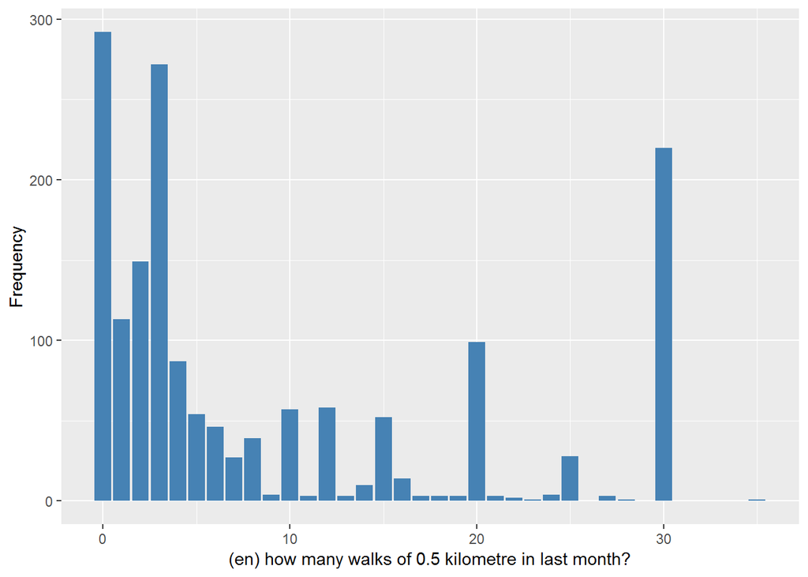

#### 2.6.1.2 Harmonisation algorithm

To compute the harmonize variable from the study-specific variable it has to be recoded as follows:

- `NA into 999`

```r
t1066_ds_Ven_w1 <- tibble(id = t1066_Ven_w1$id)
t1066_ds_Ven_w1$n_walks <- Recode(t1066_Ven_w1$PWALKOFT, "NA = '999' ")
t1066_ds_Ven_w1$n_walks <- labelled(t1066_ds_Ven_w1$n_walks, labels = c(Missing = 999,
    Do_not_know = 998, Refuse = 997, Not_applicable = 996, Does_not_answer = 995,
    Not_attempt_not_done = 994, Disable_to_measure = 993, Impute = 992, CAPI_interviewer_error = 991))
```

#### 2.6.1.3 Statistical description of the new harmonised variable

Number of walks

| Sample size | Missing values |
| --- | --- |
| 1965 | 314 |

Values

|  | No-missings | 991 | 992 | 993 | 994 | 995 | 996 | 997 | 998 | 999 | NA |
| --- | --- | --- | --- | --- | --- | --- | --- | --- | --- | --- | --- |
| Frequency | 1651.00 | 0 | 0 | 0 | 0 | 0 | 0 | 0 | 0 | 314.00 | 0 |
| Percentage | 84.02 | 0 | 0 | 0 | 0 | 0 | 0 | 0 | 0 | 15.98 | 0 |

Summary

| Min. | 1st Qu. | Median | Mean | 3rd Qu. | Max. |
| --- | --- | --- | --- | --- | --- |
| 0 | 2 | 3 | 9.056 | 15 | 35 |

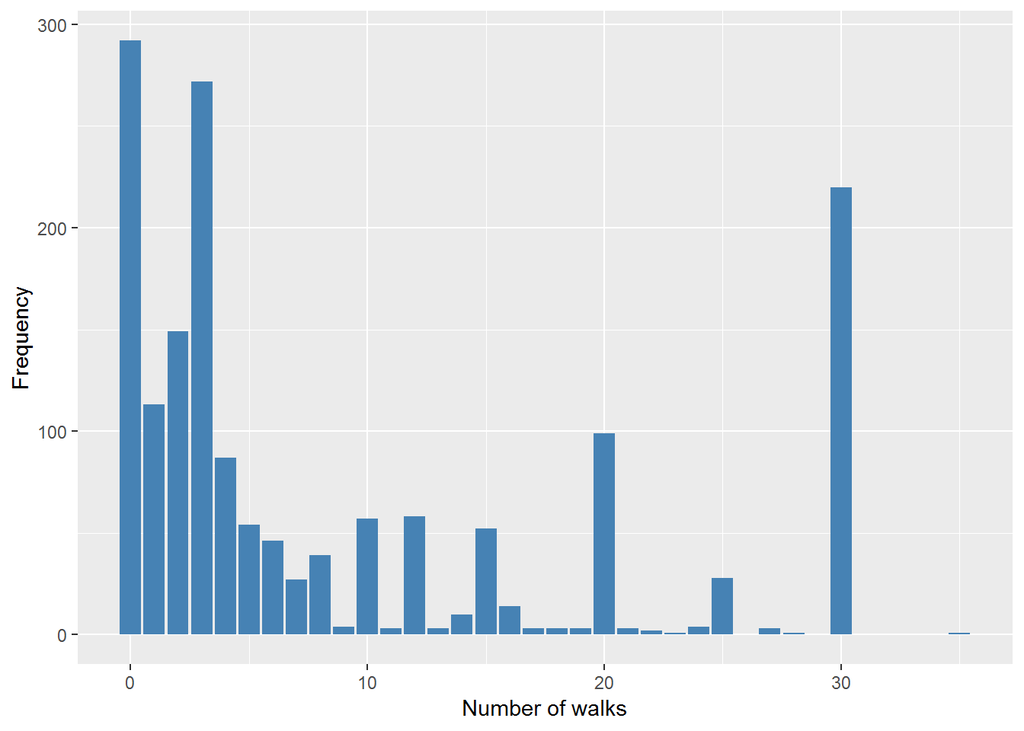

#### 2.6.1.4 Validation

|  | 0->0 | 1->1 | 2->2 | 3->3 | 4->4 | 5->5 | 6->6 | 7->7 | 8->8 | 9->9 | 10->10 | 11->11 | 12->12 | 13->13 | 14->14 | 15->15 | 16->16 | 17->17 | 18->18 | 19->19 | 20->20 | 21->21 | 22->22 | 23->23 | 24->24 | 25->25 | 27->27 | 28->28 | 30->30 | … |
| --- | --- | --- | --- | --- | --- | --- | --- | --- | --- | --- | --- | --- | --- | --- | --- | --- | --- | --- | --- | --- | --- | --- | --- | --- | --- | --- | --- | --- | --- | --- |
| BeforeH | 292 | 113 | 149 | 272 | 87 | 54 | 46 | 27 | 39 | 4 | 57 | 3 | 58 | 3 | 10 | 52 | 14 | 3 | 3 | 3 | 99 | 3 | 2 | 1 | 4 | 28 | 3 | 1 | 220 | … |
| AfterH | 292 | 113 | 149 | 272 | 87 | 54 | 46 | 27 | 39 | 4 | 57 | 3 | 58 | 3 | 10 | 52 | 14 | 3 | 3 | 3 | 99 | 3 | 2 | 1 | 4 | 28 | 3 | 1 | 220 | … |

### 2.6.2 Wave 2

#### 2.6.2.1 Study-specific variable description

| **Name** | `f_PWALKOFT` |
| --- | --- |
| **Label** | `how many walks of 0.5 kilometre in last month?` |
| **Table name** | `1066-Venezuela-Followup` |
| **Categories** | `continuous` |
| **Missings** | `999` `NA` |
| **Description** |  |

f_PWALKOFT

| Sample size | Missing values |
| --- | --- |
| 1257 | 450 |

Summary

| Min. | 1st Qu. | Median | Mean | 3rd Qu. | Max. |
| --- | --- | --- | --- | --- | --- |
| 0 | 5 | 15 | 14.05 | 20 | 40 |

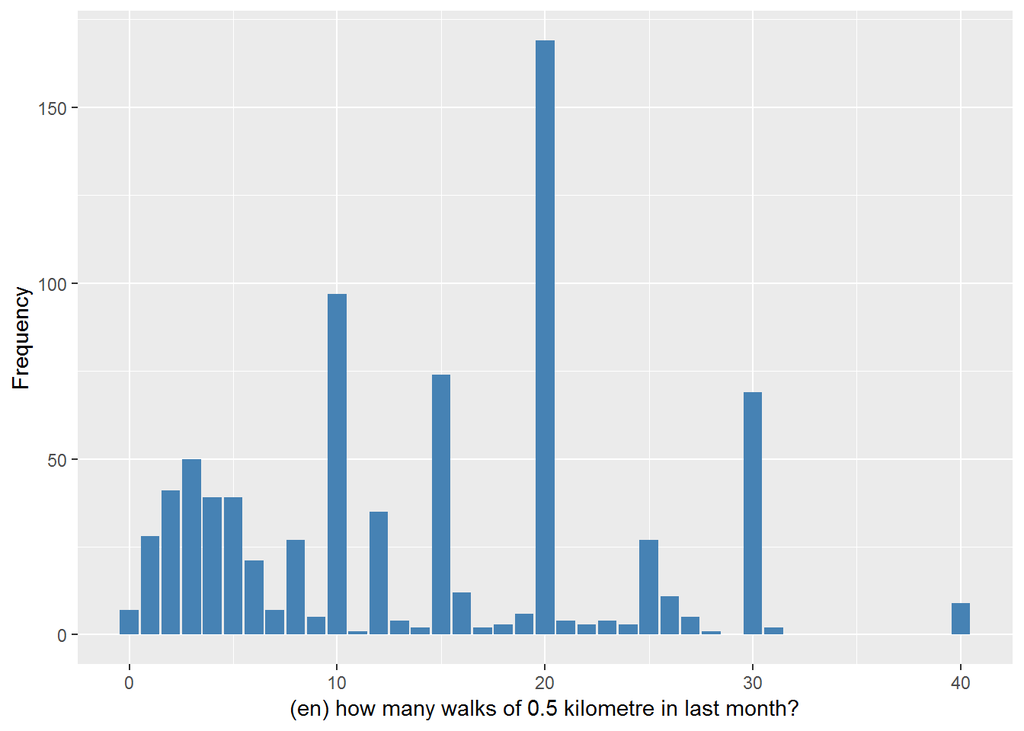

#### 2.6.2.2 Harmonisation algorithm

To compute the harmonize variable from the study-specific variable it has to be recoded as follows:

- `999 into 999`
- `NA into 999`

```r
t1066_ds_Ven_w2 <- tibble(id = t1066_Ven_w2$id)
t1066_ds_Ven_w2$n_walks <- Recode(t1066_Ven_w2$f_PWALKOFT, "NA = '999' ")
t1066_ds_Ven_w2$n_walks <- labelled(t1066_ds_Ven_w2$n_walks, labels = c(Missing = 999,
    Do_not_know = 998, Refuse = 997, Not_applicable = 996, Does_not_answer = 995,
    Not_attempt_not_done = 994, Disable_to_measure = 993, Impute = 992, CAPI_interviewer_error = 991))
```

#### 2.6.2.3 Statistical description of the new harmonised variable

Number of walks

| Sample size | Missing values |
| --- | --- |
| 1257 | 450 |

Values

|  | No-missings | 991 | 992 | 993 | 994 | 995 | 996 | 997 | 998 | 999 | NA |
| --- | --- | --- | --- | --- | --- | --- | --- | --- | --- | --- | --- |
| Frequency | 807.0 | 0 | 0 | 0 | 0 | 0 | 0 | 0 | 0 | 450.0 | 0 |
| Percentage | 64.2 | 0 | 0 | 0 | 0 | 0 | 0 | 0 | 0 | 35.8 | 0 |

Summary

| Min. | 1st Qu. | Median | Mean | 3rd Qu. | Max. |
| --- | --- | --- | --- | --- | --- |
| 0 | 5 | 15 | 14.05 | 20 | 40 |

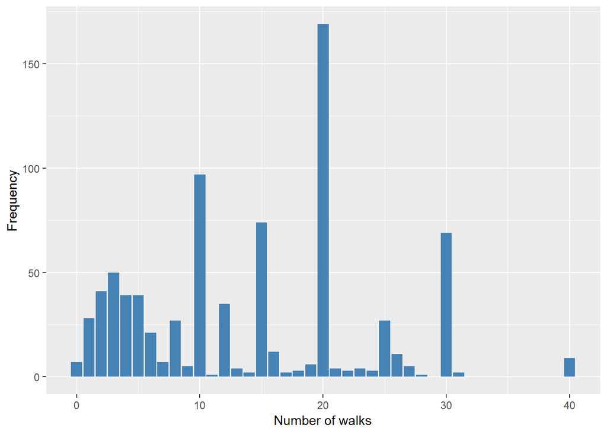

#### 2.6.2.4 Validation

|  | 0->0 | 1->1 | 2->2 | 3->3 | 4->4 | 5->5 | 6->6 | 7->7 | 8->8 | 9->9 | 10->10 | 11->11 | 12->12 | 13->13 | 14->14 | 15->15 | 16->16 | 17->17 | 18->18 | 19->19 | 20->20 | 21->21 | 22->22 | 23->23 | 24->24 | 25->25 | 26->26 | 27->27 | 28->28 | … |
| --- | --- | --- | --- | --- | --- | --- | --- | --- | --- | --- | --- | --- | --- | --- | --- | --- | --- | --- | --- | --- | --- | --- | --- | --- | --- | --- | --- | --- | --- | --- |
| BeforeH | 7 | 28 | 41 | 50 | 39 | 39 | 21 | 7 | 27 | 5 | 97 | 1 | 35 | 4 | 2 | 74 | 12 | 2 | 3 | 6 | 169 | 4 | 3 | 4 | 3 | 27 | 11 | 5 | 1 | … |
| AfterH | 7 | 28 | 41 | 50 | 39 | 39 | 21 | 7 | 27 | 5 | 97 | 1 | 35 | 4 | 2 | 74 | 12 | 2 | 3 | 6 | 169 | 4 | 3 | 4 | 3 | 27 | 11 | 5 | 1 | … |

## 2.7 Urban Peru

### 2.7.1 Wave 1

#### 2.7.1.1 Study-specific variable description

| **Name** | `PWALKOFT` |
| --- | --- |
| **Label** | `how many walks of 0.5 kilometre in last month?` |
| **Table name** | `1066-UrbanPeru-Baseline` |
| **Categories** | `continuous` |
| **Missings** | `NA` |
| **Description** |  |

PWALKOFT

| Sample size | Missing values |
| --- | --- |
| 1381 | 100 |

Summary

| Min. | 1st Qu. | Median | Mean | 3rd Qu. | Max. | NA’s |
| --- | --- | --- | --- | --- | --- | --- |
| 0 | 0 | 4 | 11.5 | 30 | 31 | 100 |

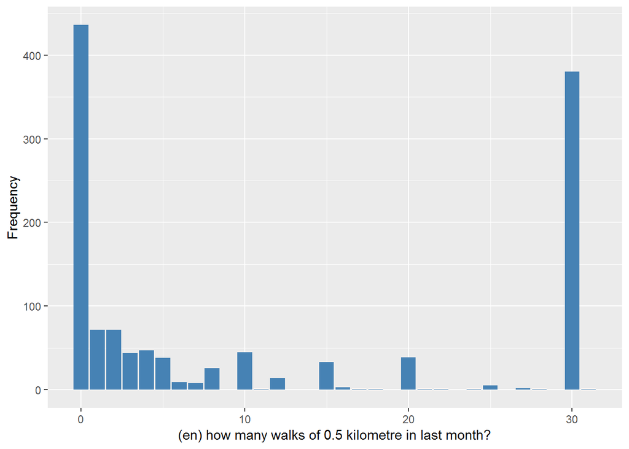

#### 2.7.1.2 Harmonisation algorithm

To compute the harmonize variable from the study-specific variable it has to be recoded as follows:

- `NA into 999`

```r
t1066_ds_UP_w1 <- tibble(id = t1066_UP_w1$id)
t1066_ds_UP_w1$n_walks <- Recode(t1066_UP_w1$PWALKOFT, "NA = '999' ")
t1066_ds_UP_w1$n_walks <- labelled(t1066_ds_UP_w1$n_walks, labels = c(Missing = 999,
    Do_not_know = 998, Refuse = 997, Not_applicable = 996, Does_not_answer = 995,
    Not_attempt_not_done = 994, Disable_to_measure = 993, Impute = 992, CAPI_interviewer_error = 991))
```

#### 2.7.1.3 Statistical description of the new harmonised variable

Number of walks

| Sample size | Missing values |
| --- | --- |
| 1381 | 100 |

Values

|  | No-missings | 991 | 992 | 993 | 994 | 995 | 996 | 997 | 998 | 999 | NA |
| --- | --- | --- | --- | --- | --- | --- | --- | --- | --- | --- | --- |
| Frequency | 1281.00 | 0 | 0 | 0 | 0 | 0 | 0 | 0 | 0 | 100.00 | 0 |
| Percentage | 92.76 | 0 | 0 | 0 | 0 | 0 | 0 | 0 | 0 | 7.24 | 0 |

Summary

| Min. | 1st Qu. | Median | Mean | 3rd Qu. | Max. |
| --- | --- | --- | --- | --- | --- |
| 0 | 0 | 4 | 11.5 | 30 | 31 |

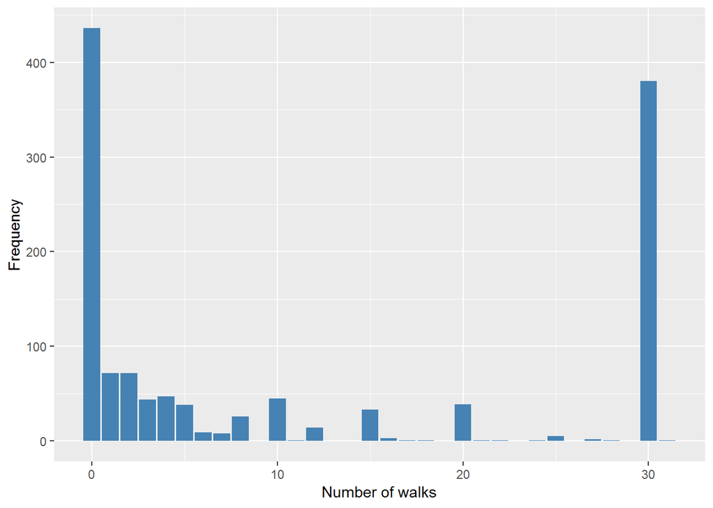

#### 2.7.1.4 Validation

|  | 0->0 | 1->1 | 2->2 | 3->3 | 4->4 | 5->5 | 6->6 | 7->7 | 8->8 | 10->10 | 11->11 | 12->12 | 15->15 | 16->16 | 17->17 | 18->18 | 20->20 | 21->21 | 22->22 | 24->24 | 25->25 | 27->27 | 28->28 | 30->30 | 31->31 | NA->999 |
| --- | --- | --- | --- | --- | --- | --- | --- | --- | --- | --- | --- | --- | --- | --- | --- | --- | --- | --- | --- | --- | --- | --- | --- | --- | --- | --- |
| BeforeH | 436 | 72 | 72 | 44 | 47 | 38 | 9 | 8 | 26 | 45 | 1 | 14 | 33 | 3 | 1 | 1 | 39 | 1 | 1 | 1 | 5 | 2 | 1 | 380 | 1 | 100 |
| AfterH | 436 | 72 | 72 | 44 | 47 | 38 | 9 | 8 | 26 | 45 | 1 | 14 | 33 | 3 | 1 | 1 | 39 | 1 | 1 | 1 | 5 | 2 | 1 | 380 | 1 | 100 |

### 2.7.2 Wave 2

#### 2.7.2.1 Study-specific variable description

| **Name** | `f_PWALKOFT` |
| --- | --- |
| **Label** | `how many walks of 0.5 kilometre in last month?` |
| **Table name** | `1066-UrbanPeru-Followup` |
| **Categories** | `continuous` |
| **Missings** | `NA` |
| **Description** |  |

f_PWALKOFT

| Sample size | Missing values |
| --- | --- |
| 890 | 443 |

Summary

| Min. | 1st Qu. | Median | Mean | 3rd Qu. | Max. | NA’s |
| --- | --- | --- | --- | --- | --- | --- |
| 0 | 3 | 8 | 12.37 | 20 | 30 | 443 |

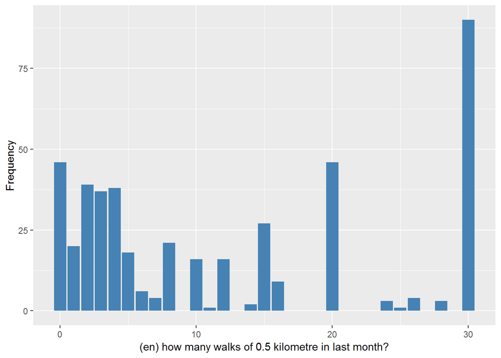

#### 2.7.2.2 Harmonisation algorithm

To compute the harmonize variable from the study-specific variable it has to be recoded as follows:

- `NA into 999`

```r
t1066_ds_UP_w2 <- tibble(id = t1066_UP_w2$id)
t1066_ds_UP_w2$n_walks <- Recode(t1066_UP_w2$f_PWALKOFT, "NA = '999' ")
t1066_ds_UP_w2$n_walks <- labelled(t1066_ds_UP_w2$n_walks, labels = c(Missing = 999,
    Do_not_know = 998, Refuse = 997, Not_applicable = 996, Does_not_answer = 995,
    Not_attempt_not_done = 994, Disable_to_measure = 993, Impute = 992, CAPI_interviewer_error = 991))
```

#### 2.7.2.3 Statistical description of the new harmonised variable

Number of walks

| Sample size | Missing values |
| --- | --- |
| 890 | 443 |

Values

|  | No-missings | 991 | 992 | 993 | 994 | 995 | 996 | 997 | 998 | 999 | NA |
| --- | --- | --- | --- | --- | --- | --- | --- | --- | --- | --- | --- |
| Frequency | 447.00 | 0 | 0 | 0 | 0 | 0 | 0 | 0 | 0 | 443.00 | 0 |
| Percentage | 50.22 | 0 | 0 | 0 | 0 | 0 | 0 | 0 | 0 | 49.78 | 0 |

Summary

| Min. | 1st Qu. | Median | Mean | 3rd Qu. | Max. |
| --- | --- | --- | --- | --- | --- |
| 0 | 3 | 8 | 12.37 | 20 | 30 |

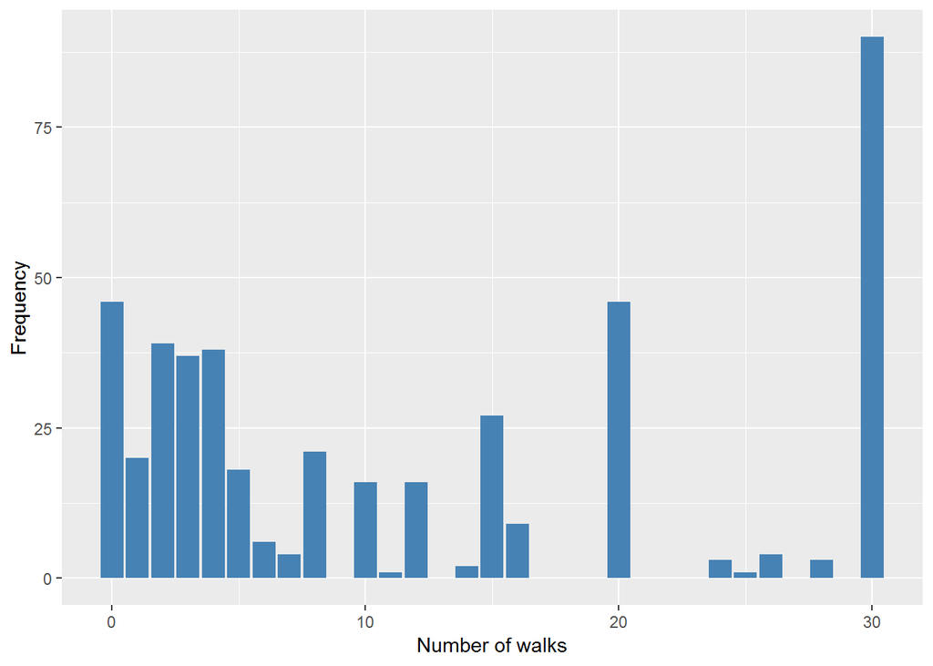

#### 2.7.2.4 Validation

|  | 0->0 | 1->1 | 2->2 | 3->3 | 4->4 | 5->5 | 6->6 | 7->7 | 8->8 | 10->10 | 11->11 | 12->12 | 14->14 | 15->15 | 16->16 | 20->20 | 24->24 | 25->25 | 26->26 | 28->28 | 30->30 | NA->999 |
| --- | --- | --- | --- | --- | --- | --- | --- | --- | --- | --- | --- | --- | --- | --- | --- | --- | --- | --- | --- | --- | --- | --- |
| BeforeH | 46 | 20 | 39 | 37 | 38 | 18 | 6 | 4 | 21 | 16 | 1 | 16 | 2 | 27 | 9 | 46 | 3 | 1 | 4 | 3 | 90 | 443 |
| AfterH | 46 | 20 | 39 | 37 | 38 | 18 | 6 | 4 | 21 | 16 | 1 | 16 | 2 | 27 | 9 | 46 | 3 | 1 | 4 | 3 | 90 | 443 |

## 2.8 Rural Peru

### 2.8.1 Wave 1

#### 2.8.1.1 Study-specific variable description

| **Name** | `PWALKOFT` |
| --- | --- |
| **Label** | `how many walks of 0.5 kilometre in last month?` |
| **Table name** | `1066-RuralPeru-Baseline` |
| **Categories** | `continuous` |
| **Missings** | `NA` |
| **Description** |  |

PWALKOFT

| Sample size | Missing values |
| --- | --- |
| 552 | 7 |

Summary

| Min. | 1st Qu. | Median | Mean | 3rd Qu. | Max. | NA’s |
| --- | --- | --- | --- | --- | --- | --- |
| 0 | 0 | 3 | 6.886 | 5 | 30 | 7 |

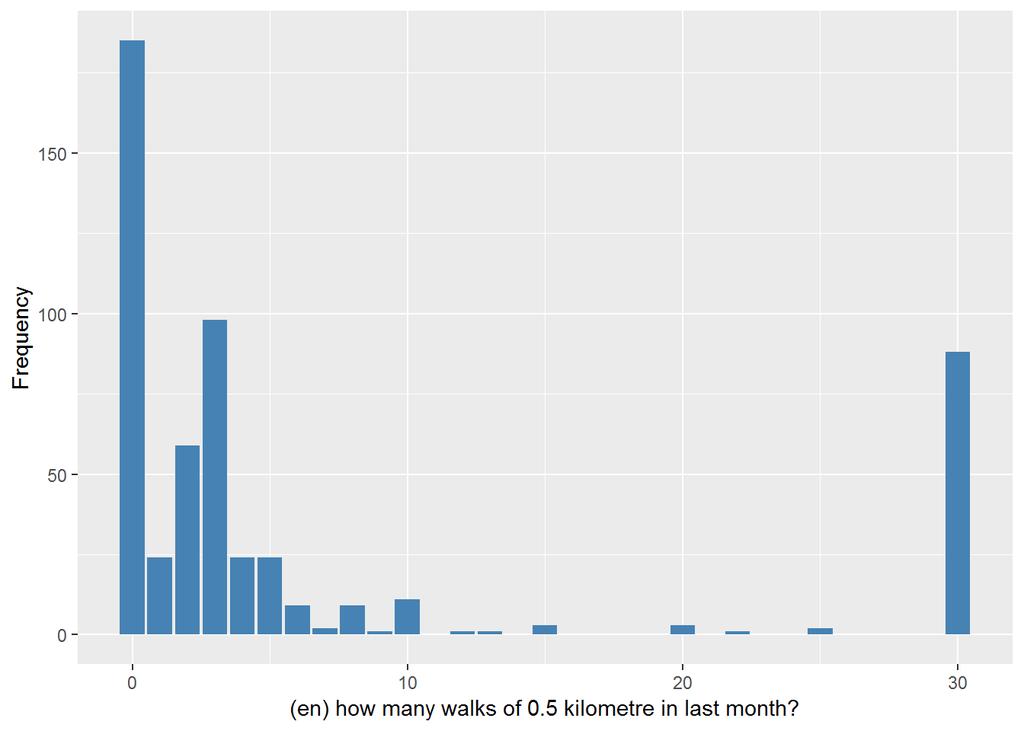

#### 2.8.1.2 Harmonisation algorithm

To compute the harmonize variable from the study-specific variable it has to be recoded as follows:

- `NA into 999`

```r
t1066_ds_RP_w1 <- tibble(id = t1066_RP_w1$id)
t1066_ds_RP_w1$n_walks <- Recode(t1066_RP_w1$PWALKOFT, "NA = '999' ")
t1066_ds_RP_w1$n_walks <- labelled(t1066_ds_RP_w1$n_walks, labels = c(Missing = 999,
    Do_not_know = 998, Refuse = 997, Not_applicable = 996, Does_not_answer = 995,
    Not_attempt_not_done = 994, Disable_to_measure = 993, Impute = 992, CAPI_interviewer_error = 991))
```

#### 2.8.1.3 Statistical description of the new harmonised variable

Number of walks

| Sample size | Missing values |
| --- | --- |
| 552 | 7 |

Values

|  | No-missings | 991 | 992 | 993 | 994 | 995 | 996 | 997 | 998 | 999 | NA |
| --- | --- | --- | --- | --- | --- | --- | --- | --- | --- | --- | --- |
| Frequency | 545.00 | 0 | 0 | 0 | 0 | 0 | 0 | 0 | 0 | 7.00 | 0 |
| Percentage | 98.73 | 0 | 0 | 0 | 0 | 0 | 0 | 0 | 0 | 1.27 | 0 |

Summary

| Min. | 1st Qu. | Median | Mean | 3rd Qu. | Max. |
| --- | --- | --- | --- | --- | --- |
| 0 | 0 | 3 | 6.886 | 5 | 30 |

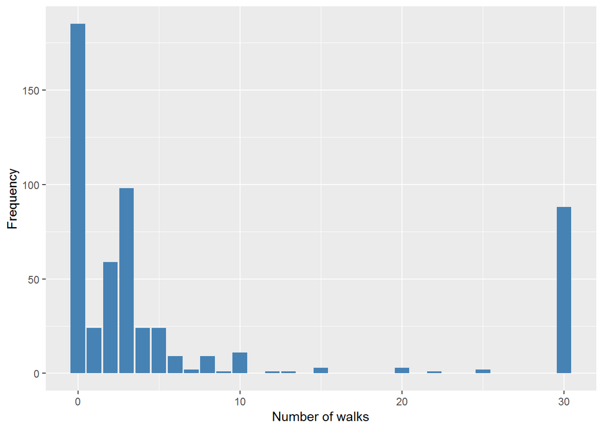

#### 2.8.1.4 Validation

|  | 0->0 | 1->1 | 2->2 | 3->3 | 4->4 | 5->5 | 6->6 | 7->7 | 8->8 | 9->9 | 10->10 | 12->12 | 13->13 | 15->15 | 20->20 | 22->22 | 25->25 | 30->30 | NA->999 |
| --- | --- | --- | --- | --- | --- | --- | --- | --- | --- | --- | --- | --- | --- | --- | --- | --- | --- | --- | --- |
| BeforeH | 185 | 24 | 59 | 98 | 24 | 24 | 9 | 2 | 9 | 1 | 11 | 1 | 1 | 3 | 3 | 1 | 2 | 88 | 7 |
| AfterH | 185 | 24 | 59 | 98 | 24 | 24 | 9 | 2 | 9 | 1 | 11 | 1 | 1 | 3 | 3 | 1 | 2 | 88 | 7 |

### 2.8.2 Wave 2

#### 2.8.2.1 Study-specific variable description

| **Name** | `f_PWALKOFT` |
| --- | --- |
| **Label** | `how many walks of 0.5 kilometre in last month?` |
| **Table name** | `1066-RuralPeru-Followup` |
| **Categories** | `continuous` |
| **Missings** | `NA` |
| **Description** |  |

f_PWALKOFT

| Sample size | Missing values |
| --- | --- |
| 421 | 272 |

Summary

| Min. | 1st Qu. | Median | Mean | 3rd Qu. | Max. | NA’s |
| --- | --- | --- | --- | --- | --- | --- |
| 0 | 4 | 7 | 12.91 | 30 | 30 | 272 |

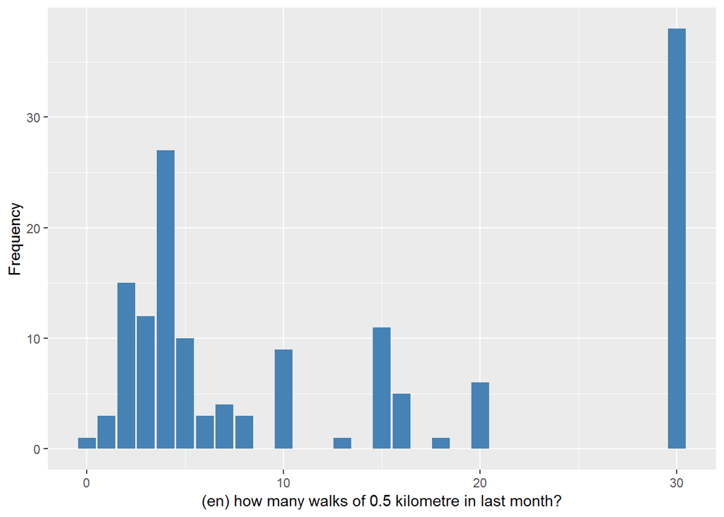

#### 2.8.2.2 Harmonisation algorithm

To compute the harmonize variable from the study-specific variable it has to be recoded as follows:

- `NA into 999`

```r
t1066_ds_RP_w2 <- tibble(id = t1066_RP_w2$id)
t1066_ds_RP_w2$n_walks <- Recode(t1066_RP_w2$f_PWALKOFT, "NA = '999' ")
t1066_ds_RP_w2$n_walks <- labelled(t1066_ds_RP_w2$n_walks, labels = c(Missing = 999,
    Do_not_know = 998, Refuse = 997, Not_applicable = 996, Does_not_answer = 995,
    Not_attempt_not_done = 994, Disable_to_measure = 993, Impute = 992, CAPI_interviewer_error = 991))
```

#### 2.8.2.3 Statistical description of the new harmonised variable

Number of walks

| Sample size | Missing values |
| --- | --- |
| 421 | 272 |

Values

|  | No-missings | 991 | 992 | 993 | 994 | 995 | 996 | 997 | 998 | 999 | NA |
| --- | --- | --- | --- | --- | --- | --- | --- | --- | --- | --- | --- |
| Frequency | 149.00 | 0 | 0 | 0 | 0 | 0 | 0 | 0 | 0 | 272.00 | 0 |
| Percentage | 35.39 | 0 | 0 | 0 | 0 | 0 | 0 | 0 | 0 | 64.61 | 0 |

Summary

| Min. | 1st Qu. | Median | Mean | 3rd Qu. | Max. |
| --- | --- | --- | --- | --- | --- |
| 0 | 4 | 7 | 12.91 | 30 | 30 |

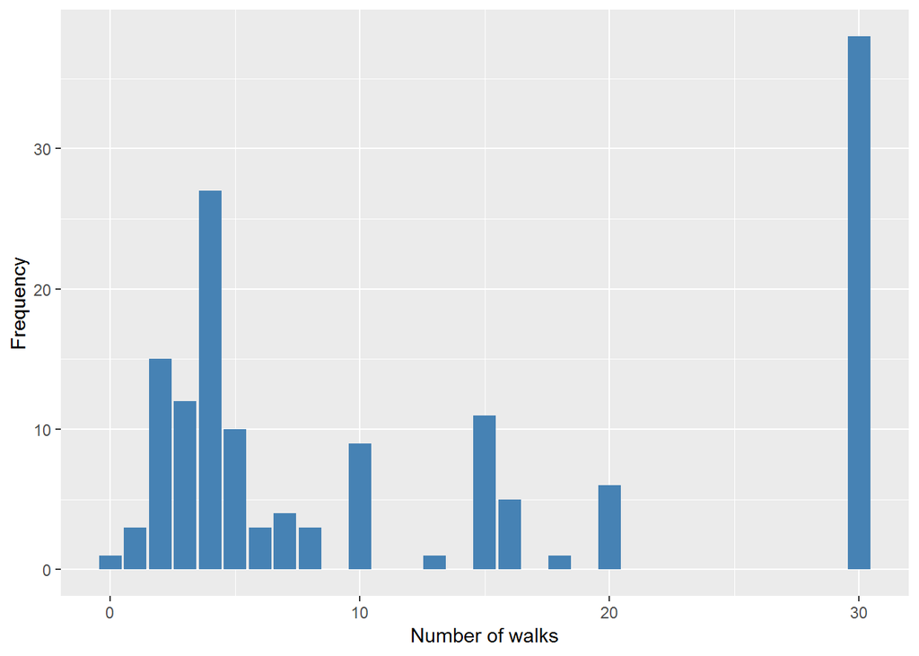

#### 2.8.2.4 Validation

|  | 0->0 | 1->1 | 2->2 | 3->3 | 4->4 | 5->5 | 6->6 | 7->7 | 8->8 | 10->10 | 13->13 | 15->15 | 16->16 | 18->18 | 20->20 | 30->30 | NA->999 |
| --- | --- | --- | --- | --- | --- | --- | --- | --- | --- | --- | --- | --- | --- | --- | --- | --- | --- |
| BeforeH | 1 | 3 | 15 | 12 | 27 | 10 | 3 | 4 | 3 | 9 | 1 | 11 | 5 | 1 | 6 | 38 | 272 |
| AfterH | 1 | 3 | 15 | 12 | 27 | 10 | 3 | 4 | 3 | 9 | 1 | 11 | 5 | 1 | 6 | 38 | 272 |

## 2.9 Urban Mexico

### 2.9.1 Wave 1

#### 2.9.1.1 Study-specific variable description

| **Name** | `PWALKOFT` |
| --- | --- |
| **Label** | `how many walks of 0.5 kilometre in last month?` |
| **Table name** | `1066-UrbanMexico-Baseline` |
| **Categories** | `continuous` |
| **Missings** | `NA` |
| **Description** |  |

PWALKOFT

| Sample size | Missing values |
| --- | --- |
| 1003 | 19 |

Summary

| Min. | 1st Qu. | Median | Mean | 3rd Qu. | Max. | NA’s |
| --- | --- | --- | --- | --- | --- | --- |
| 0 | 0 | 3 | 7.702 | 12 | 38 | 19 |

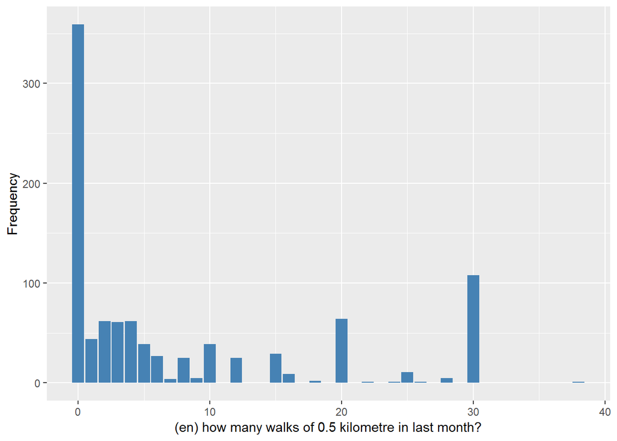

#### 2.9.1.2 Harmonisation algorithm

To compute the harmonize variable from the study-specific variable it has to be recoded as follows:

- `NA into 999`

```r
t1066_ds_UM_w1 <- tibble(id = t1066_UM_w1$id)
t1066_ds_UM_w1$n_walks <- Recode(t1066_UM_w1$PWALKOFT, "NA = '999' ")
t1066_ds_UM_w1$n_walks <- labelled(t1066_ds_UM_w1$n_walks, labels = c(Missing = 999,
    Do_not_know = 998, Refuse = 997, Not_applicable = 996, Does_not_answer = 995,
    Not_attempt_not_done = 994, Disable_to_measure = 993, Impute = 992, CAPI_interviewer_error = 991))
```

#### 2.9.1.3 Statistical description of the new harmonised variable

Number of walks

| Sample size | Missing values |
| --- | --- |
| 1003 | 19 |

Values

|  | No-missings | 991 | 992 | 993 | 994 | 995 | 996 | 997 | 998 | 999 | NA |
| --- | --- | --- | --- | --- | --- | --- | --- | --- | --- | --- | --- |
| Frequency | 984.00 | 0 | 0 | 0 | 0 | 0 | 0 | 0 | 0 | 19.00 | 0 |
| Percentage | 98.11 | 0 | 0 | 0 | 0 | 0 | 0 | 0 | 0 | 1.89 | 0 |

Summary

| Min. | 1st Qu. | Median | Mean | 3rd Qu. | Max. |
| --- | --- | --- | --- | --- | --- |
| 0 | 0 | 3 | 7.702 | 12 | 38 |

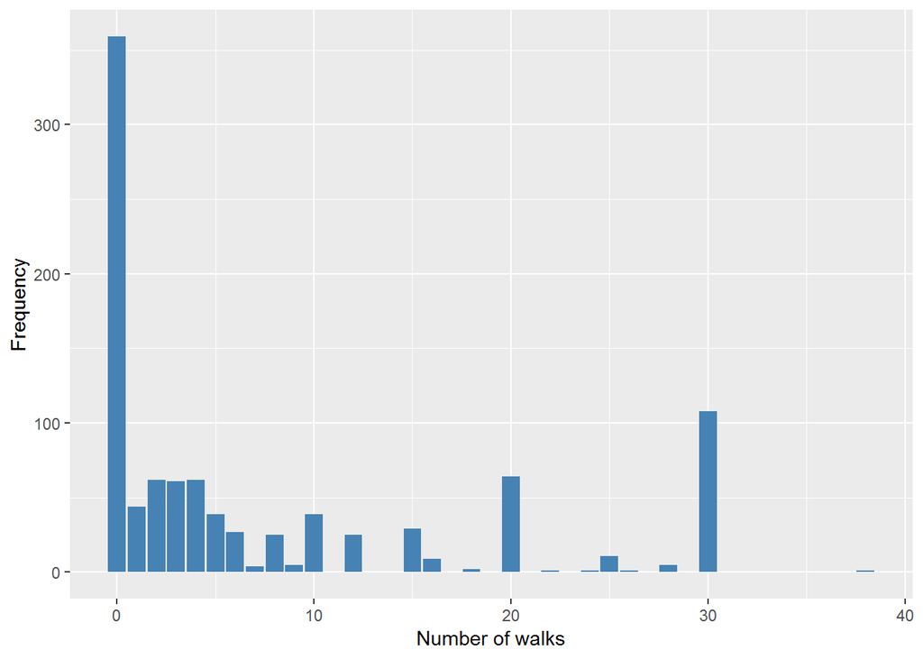

#### 2.9.1.4 Validation

|  | 0->0 | 1->1 | 2->2 | 3->3 | 4->4 | 5->5 | 6->6 | 7->7 | 8->8 | 9->9 | 10->10 | 12->12 | 15->15 | 16->16 | 18->18 | 20->20 | 22->22 | 24->24 | 25->25 | 26->26 | 28->28 | 30->30 | 38->38 | NA->999 |
| --- | --- | --- | --- | --- | --- | --- | --- | --- | --- | --- | --- | --- | --- | --- | --- | --- | --- | --- | --- | --- | --- | --- | --- | --- |
| BeforeH | 359 | 44 | 62 | 61 | 62 | 39 | 27 | 4 | 25 | 5 | 39 | 25 | 29 | 9 | 2 | 64 | 1 | 1 | 11 | 1 | 5 | 108 | 1 | 19 |
| AfterH | 359 | 44 | 62 | 61 | 62 | 39 | 27 | 4 | 25 | 5 | 39 | 25 | 29 | 9 | 2 | 64 | 1 | 1 | 11 | 1 | 5 | 108 | 1 | 19 |

### 2.9.2 Wave 2

#### 2.9.2.1 Study-specific variable description

| **Name** | `f_PWALKOFT` |
| --- | --- |
| **Label** | `how many walks of 0.5 kilometre in last month?` |
| **Table name** | `1066-UrbanMexico-Followup` |
| **Categories** | `continuous` |
| **Missings** | `999` `NA` |
| **Description** |  |

f_PWALKOFT

| Sample size | Missing values |
| --- | --- |
| 749 | 281 |

Summary

| Min. | 1st Qu. | Median | Mean | 3rd Qu. | Max. |
| --- | --- | --- | --- | --- | --- |
| 0 | 4 | 8 | 12.31 | 20 | 120 |

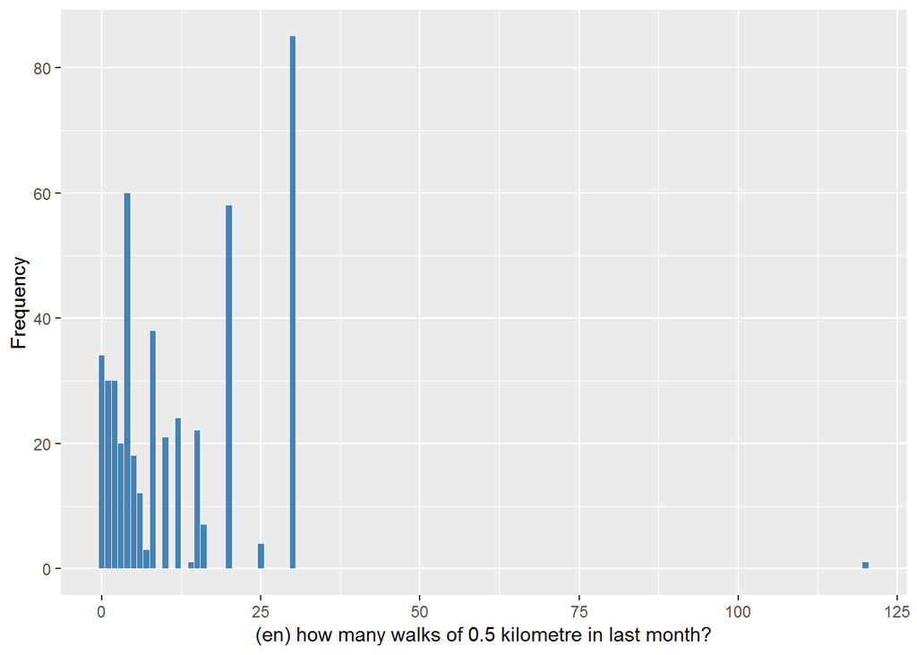

#### 2.9.2.2 Harmonisation algorithm

To compute the harmonize variable from the study-specific variable it has to be recoded as follows:

- `999 into 999`
- `NA into 999`

```r
t1066_ds_UM_w2 <- tibble(id = t1066_UM_w2$id)
t1066_ds_UM_w2$n_walks <- Recode(t1066_UM_w2$f_PWALKOFT, "NA = '999' ")
t1066_ds_UM_w2$n_walks <- labelled(t1066_ds_UM_w2$n_walks, labels = c(Missing = 999,
    Do_not_know = 998, Refuse = 997, Not_applicable = 996, Does_not_answer = 995,
    Not_attempt_not_done = 994, Disable_to_measure = 993, Impute = 992, CAPI_interviewer_error = 991))
```

#### 2.9.2.3 Statistical description of the new harmonised variable

Number of walks

| Sample size | Missing values |
| --- | --- |
| 749 | 281 |

Values

|  | No-missings | 991 | 992 | 993 | 994 | 995 | 996 | 997 | 998 | 999 | NA |
| --- | --- | --- | --- | --- | --- | --- | --- | --- | --- | --- | --- |
| Frequency | 468.00 | 0 | 0 | 0 | 0 | 0 | 0 | 0 | 0 | 281.00 | 0 |
| Percentage | 62.48 | 0 | 0 | 0 | 0 | 0 | 0 | 0 | 0 | 37.52 | 0 |

Summary

| Min. | 1st Qu. | Median | Mean | 3rd Qu. | Max. |
| --- | --- | --- | --- | --- | --- |
| 0 | 4 | 8 | 12.31 | 20 | 120 |

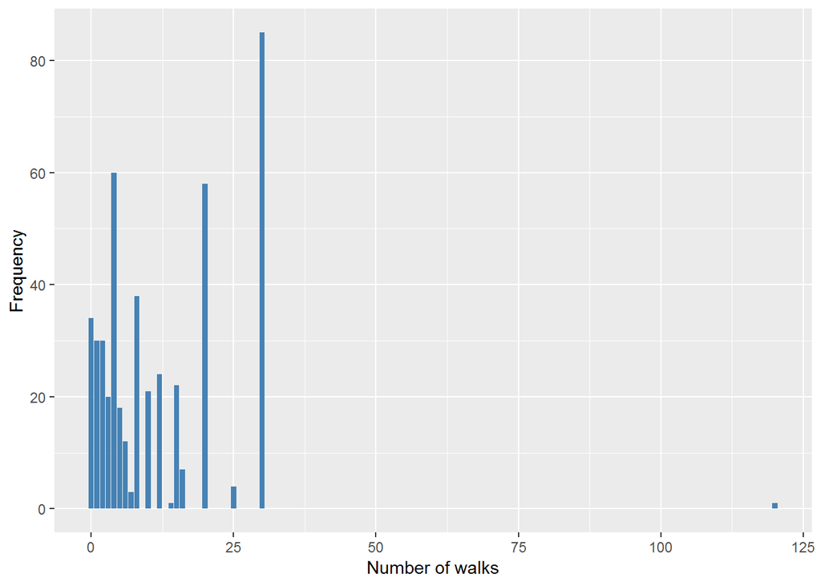

#### 2.9.2.4 Validation

|  | 0->0 | 1->1 | 2->2 | 3->3 | 4->4 | 5->5 | 6->6 | 7->7 | 8->8 | 10->10 | 12->12 | 14->14 | 15->15 | 16->16 | 20->20 | 25->25 | 30->30 | 120->120 | 999,NA->999 |
| --- | --- | --- | --- | --- | --- | --- | --- | --- | --- | --- | --- | --- | --- | --- | --- | --- | --- | --- | --- |
| BeforeH | 34 | 30 | 30 | 20 | 60 | 18 | 12 | 3 | 38 | 21 | 24 | 1 | 22 | 7 | 58 | 4 | 85 | 1 | 281 |
| AfterH | 34 | 30 | 30 | 20 | 60 | 18 | 12 | 3 | 38 | 21 | 24 | 1 | 22 | 7 | 58 | 4 | 85 | 1 | 281 |

## 2.10 Rural Mexico

### 2.10.1 Wave 1

#### 2.10.1.1 Study-specific variable description

| **Name** | `PWALKOFT` |
| --- | --- |
| **Label** | `how many walks of 0.5 kilometre in last month?` |
| **Table name** | `1066-RuralMexico-Baseline` |
| **Categories** | `continuous` |
| **Missings** | `NA` |
| **Description** |  |

PWALKOFT

| Sample size | Missing values |
| --- | --- |
| 1000 | 21 |

Summary

| Min. | 1st Qu. | Median | Mean | 3rd Qu. | Max. | NA’s |
| --- | --- | --- | --- | --- | --- | --- |
| 0 | 0 | 5 | 10.5 | 20 | 30 | 21 |

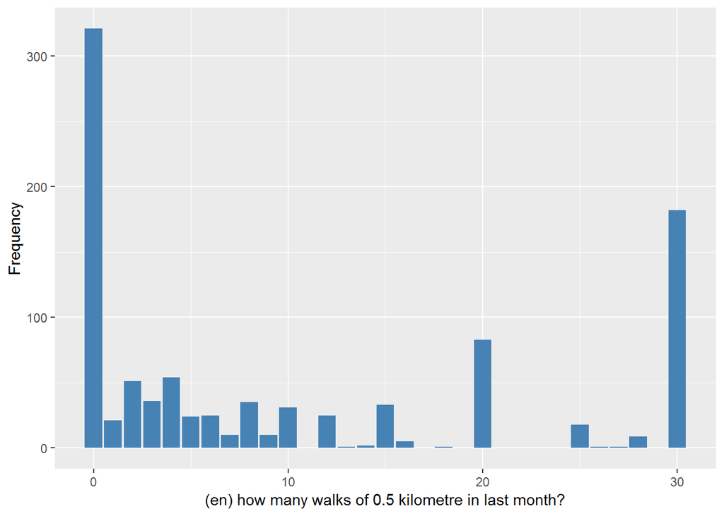

#### 2.10.1.2 Harmonisation algorithm

To compute the harmonize variable from the study-specific variable it has to be recoded as follows:

- `NA into 999`

```r
t1066_ds_RM_w1 <- tibble(id = t1066_RM_w1$id)
t1066_ds_RM_w1$n_walks <- Recode(t1066_RM_w1$PWALKOFT, "NA = '999' ")
t1066_ds_RM_w1$n_walks <- labelled(t1066_ds_RM_w1$n_walks, labels = c(Missing = 999,
    Do_not_know = 998, Refuse = 997, Not_applicable = 996, Does_not_answer = 995,
    Not_attempt_not_done = 994, Disable_to_measure = 993, Impute = 992, CAPI_interviewer_error = 991))
```

#### 2.10.1.3 Statistical description of the new harmonised variable

Number of walks

| Sample size | Missing values |
| --- | --- |
| 1000 | 21 |

Values

|  | No-missings | 991 | 992 | 993 | 994 | 995 | 996 | 997 | 998 | 999 | NA |
| --- | --- | --- | --- | --- | --- | --- | --- | --- | --- | --- | --- |
| Frequency | 979.0 | 0 | 0 | 0 | 0 | 0 | 0 | 0 | 0 | 21.0 | 0 |
| Percentage | 97.9 | 0 | 0 | 0 | 0 | 0 | 0 | 0 | 0 | 2.1 | 0 |

Summary

| Min. | 1st Qu. | Median | Mean | 3rd Qu. | Max. |
| --- | --- | --- | --- | --- | --- |
| 0 | 0 | 5 | 10.5 | 20 | 30 |

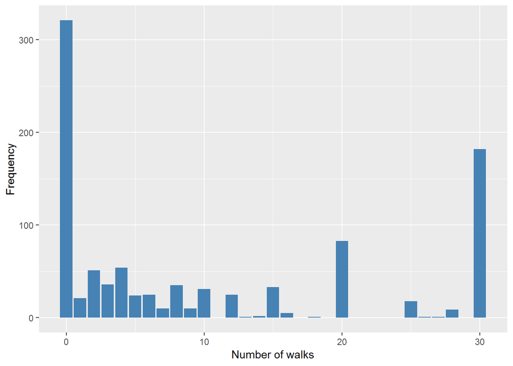

#### 2.10.1.4 Validation

|  | 0->0 | 1->1 | 2->2 | 3->3 | 4->4 | 5->5 | 6->6 | 7->7 | 8->8 | 9->9 | 10->10 | 12->12 | 13->13 | 14->14 | 15->15 | 16->16 | 18->18 | 20->20 | 25->25 | 26->26 | 27->27 | 28->28 | 30->30 | NA->999 |
| --- | --- | --- | --- | --- | --- | --- | --- | --- | --- | --- | --- | --- | --- | --- | --- | --- | --- | --- | --- | --- | --- | --- | --- | --- |
| BeforeH | 321 | 21 | 51 | 36 | 54 | 24 | 25 | 10 | 35 | 10 | 31 | 25 | 1 | 2 | 33 | 5 | 1 | 83 | 18 | 1 | 1 | 9 | 182 | 21 |
| AfterH | 321 | 21 | 51 | 36 | 54 | 24 | 25 | 10 | 35 | 10 | 31 | 25 | 1 | 2 | 33 | 5 | 1 | 83 | 18 | 1 | 1 | 9 | 182 | 21 |

### 2.10.2 Wave 2

#### 2.10.2.1 Study-specific variable description

| **Name** | `f_PWALKOFT` |
| --- | --- |
| **Label** | `how many walks of 0.5 kilometre in last month?` |
| **Table name** | `1066-RuralMexico-Followup` |
| **Categories** | `continuous` |
| **Missings** | `NA` |
| **Description** |  |

f_PWALKOFT

| Sample size | Missing values |
| --- | --- |
| 713 | 255 |

Summary

| Min. | 1st Qu. | Median | Mean | 3rd Qu. | Max. | NA’s |
| --- | --- | --- | --- | --- | --- | --- |
| 0 | 4 | 20 | 17.83 | 30 | 40 | 255 |

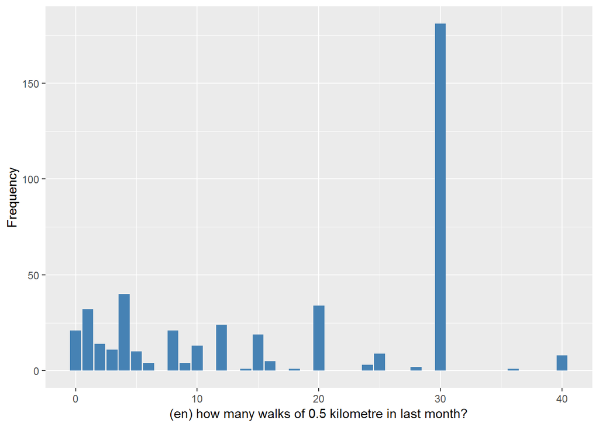

#### 2.10.2.2 Harmonisation algorithm

To compute the harmonize variable from the study-specific variable it has to be recoded as follows:

- `NA into 999`

```r
t1066_ds_RM_w2 <- tibble(id = t1066_RM_w2$id)
t1066_ds_RM_w2$n_walks <- Recode(t1066_RM_w2$f_PWALKOFT, "NA = '999' ")
t1066_ds_RM_w2$n_walks <- labelled(t1066_ds_RM_w2$n_walks, labels = c(Missing = 999,
    Do_not_know = 998, Refuse = 997, Not_applicable = 996, Does_not_answer = 995,
    Not_attempt_not_done = 994, Disable_to_measure = 993, Impute = 992, CAPI_interviewer_error = 991))
```

#### 2.10.2.3 Statistical description of the new harmonised variable

Number of walks

| Sample size | Missing values |
| --- | --- |
| 713 | 255 |

Values

|  | No-missings | 991 | 992 | 993 | 994 | 995 | 996 | 997 | 998 | 999 | NA |
| --- | --- | --- | --- | --- | --- | --- | --- | --- | --- | --- | --- |
| Frequency | 458.00 | 0 | 0 | 0 | 0 | 0 | 0 | 0 | 0 | 255.00 | 0 |
| Percentage | 64.24 | 0 | 0 | 0 | 0 | 0 | 0 | 0 | 0 | 35.76 | 0 |

Summary

| Min. | 1st Qu. | Median | Mean | 3rd Qu. | Max. |
| --- | --- | --- | --- | --- | --- |
| 0 | 4 | 20 | 17.83 | 30 | 40 |

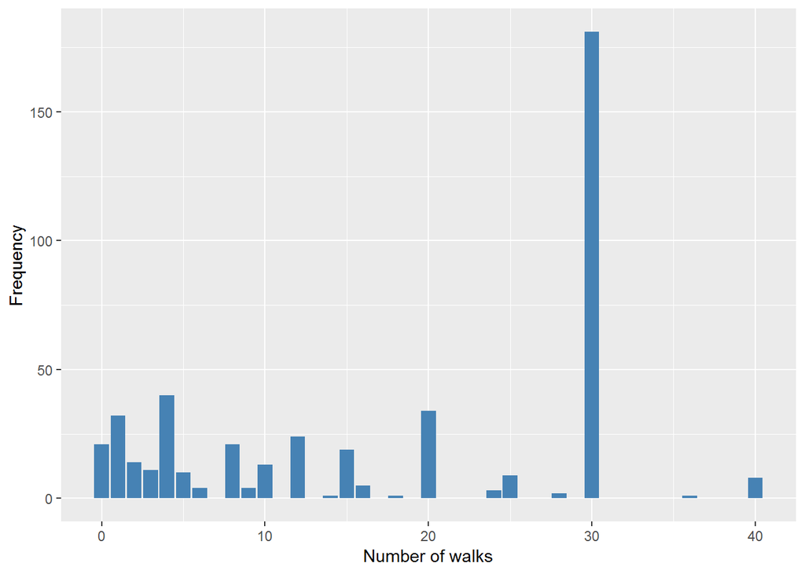

#### 2.10.2.4 Validation

|  | 0->0 | 1->1 | 2->2 | 3->3 | 4->4 | 5->5 | 6->6 | 8->8 | 9->9 | 10->10 | 12->12 | 14->14 | 15->15 | 16->16 | 18->18 | 20->20 | 24->24 | 25->25 | 28->28 | 30->30 | 36->36 | 40->40 | NA->999 |
| --- | --- | --- | --- | --- | --- | --- | --- | --- | --- | --- | --- | --- | --- | --- | --- | --- | --- | --- | --- | --- | --- | --- | --- |
| BeforeH | 21 | 32 | 14 | 11 | 40 | 10 | 4 | 21 | 4 | 13 | 24 | 1 | 19 | 5 | 1 | 34 | 3 | 9 | 2 | 181 | 1 | 8 | 255 |
| AfterH | 21 | 32 | 14 | 11 | 40 | 10 | 4 | 21 | 4 | 13 | 24 | 1 | 19 | 5 | 1 | 34 | 3 | 9 | 2 | 181 | 1 | 8 | 255 |

## 2.11 Puerto Rico

### 2.11.1 Wave 1

#### 2.11.1.1 Study-specific variable description

| **Name** | `PWALKOFT` |
| --- | --- |
| **Label** | `how many walks of 0.5 kilometre in last month?` |
| **Table name** | `1066-PuertoRico-Baseline` |
| **Categories** | `continuous` |
| **Missings** | `NA` |
| **Description** |  |

PWALKOFT

| Sample size | Missing values |
| --- | --- |
| 2009 | 8 |

Summary

| Min. | 1st Qu. | Median | Mean | 3rd Qu. | Max. | NA’s |
| --- | --- | --- | --- | --- | --- | --- |
| 0 | 0 | 0 | 5.068 | 5 | 30 | 8 |

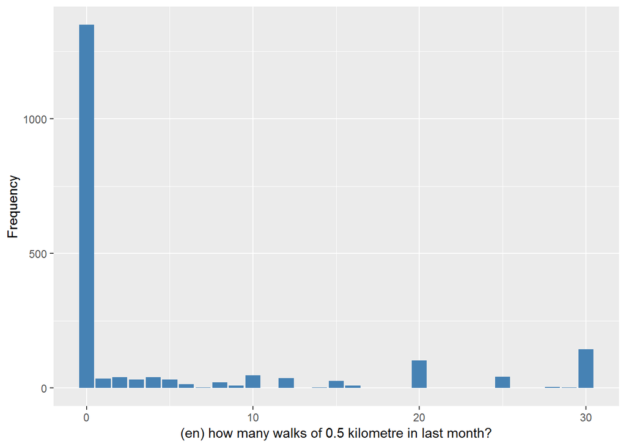

#### 2.11.1.2 Harmonisation algorithm

To compute the harmonize variable from the study-specific variable it has to be recoded as follows:

- `NA into 999`

```r
t1066_ds_PR_w1 <- tibble(id = t1066_PR_w1$id)
t1066_ds_PR_w1$n_walks <- Recode(t1066_PR_w1$PWALKOFT, "NA = '999' ")
t1066_ds_PR_w1$n_walks <- labelled(t1066_ds_PR_w1$n_walks, labels = c(Missing = 999,
    Do_not_know = 998, Refuse = 997, Not_applicable = 996, Does_not_answer = 995,
    Not_attempt_not_done = 994, Disable_to_measure = 993, Impute = 992, CAPI_interviewer_error = 991))
```

#### 2.11.1.3 Statistical description of the new harmonised variable

Number of walks

| Sample size | Missing values |
| --- | --- |
| 2009 | 8 |

Values

|  | No-missings | 991 | 992 | 993 | 994 | 995 | 996 | 997 | 998 | 999 | NA |
| --- | --- | --- | --- | --- | --- | --- | --- | --- | --- | --- | --- |
| Frequency | 2001.0 | 0 | 0 | 0 | 0 | 0 | 0 | 0 | 0 | 8.0 | 0 |
| Percentage | 99.6 | 0 | 0 | 0 | 0 | 0 | 0 | 0 | 0 | 0.4 | 0 |

Summary

| Min. | 1st Qu. | Median | Mean | 3rd Qu. | Max. |
| --- | --- | --- | --- | --- | --- |
| 0 | 0 | 0 | 5.068 | 5 | 30 |

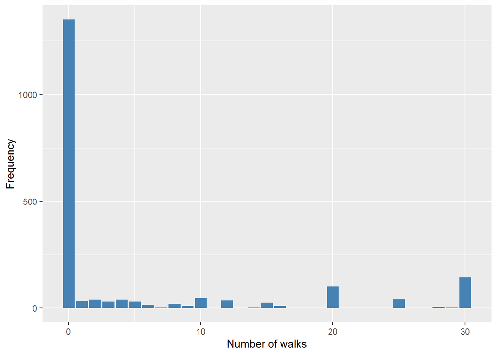

#### 2.11.1.4 Validation

|  | 0->0 | 1->1 | 2->2 | 3->3 | 4->4 | 5->5 | 6->6 | 7->7 | 8->8 | 9->9 | 10->10 | 12->12 | 14->14 | 15->15 | 16->16 | 18->18 | 20->20 | 22->22 | 24->24 | 25->25 | 28->28 | 29->29 | 30->30 | NA->999 |
| --- | --- | --- | --- | --- | --- | --- | --- | --- | --- | --- | --- | --- | --- | --- | --- | --- | --- | --- | --- | --- | --- | --- | --- | --- |
| BeforeH | 1349 | 36 | 41 | 31 | 41 | 32 | 14 | 3 | 21 | 9 | 47 | 37 | 3 | 27 | 9 | 1 | 103 | 1 | 1 | 43 | 4 | 3 | 145 | 8 |
| AfterH | 1349 | 36 | 41 | 31 | 41 | 32 | 14 | 3 | 21 | 9 | 47 | 37 | 3 | 27 | 9 | 1 | 103 | 1 | 1 | 43 | 4 | 3 | 145 | 8 |

### 2.11.2 Wave 2

#### 2.11.2.1 Study-specific variable description

| **Name** | `f_PWALKOFT` |
| --- | --- |
| **Label** | `how many walks of 0.5 kilometre in last month?` |
| **Table name** | `1066-PuertoRico-Followup` |
| **Categories** | `continuous` |
| **Missings** | `NA` |
| **Description** |  |

f_PWALKOFT

| Sample size | Missing values |
| --- | --- |
| 1265 | 875 |

Summary

| Min. | 1st Qu. | Median | Mean | 3rd Qu. | Max. | NA’s |
| --- | --- | --- | --- | --- | --- | --- |
| 0 | 0 | 3 | 7.721 | 16 | 30 | 875 |

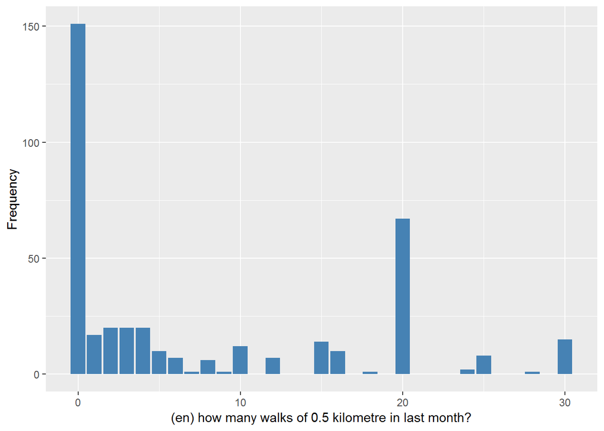

#### 2.11.2.2 Harmonisation algorithm

To compute the harmonize variable from the study-specific variable it has to be recoded as follows:

- `NA into 999`

```r
t1066_ds_PR_w2 <- tibble(id = t1066_PR_w2$id)
t1066_ds_PR_w2$n_walks <- Recode(t1066_PR_w2$f_PWALKOFT, "NA = '999' ")
t1066_ds_PR_w2$n_walks <- labelled(t1066_ds_PR_w2$n_walks, labels = c(Missing = 999,
    Do_not_know = 998, Refuse = 997, Not_applicable = 996, Does_not_answer = 995,
    Not_attempt_not_done = 994, Disable_to_measure = 993, Impute = 992, CAPI_interviewer_error = 991))
```

#### 2.11.2.3 Statistical description of the new harmonised variable

Number of walks

| Sample size | Missing values |
| --- | --- |
| 1265 | 875 |

Values

|  | No-missings | 991 | 992 | 993 | 994 | 995 | 996 | 997 | 998 | 999 | NA |
| --- | --- | --- | --- | --- | --- | --- | --- | --- | --- | --- | --- |
| Frequency | 390.00 | 0 | 0 | 0 | 0 | 0 | 0 | 0 | 0 | 875.00 | 0 |
| Percentage | 30.83 | 0 | 0 | 0 | 0 | 0 | 0 | 0 | 0 | 69.17 | 0 |

Summary

| Min. | 1st Qu. | Median | Mean | 3rd Qu. | Max. |
| --- | --- | --- | --- | --- | --- |
| 0 | 0 | 3 | 7.721 | 16 | 30 |

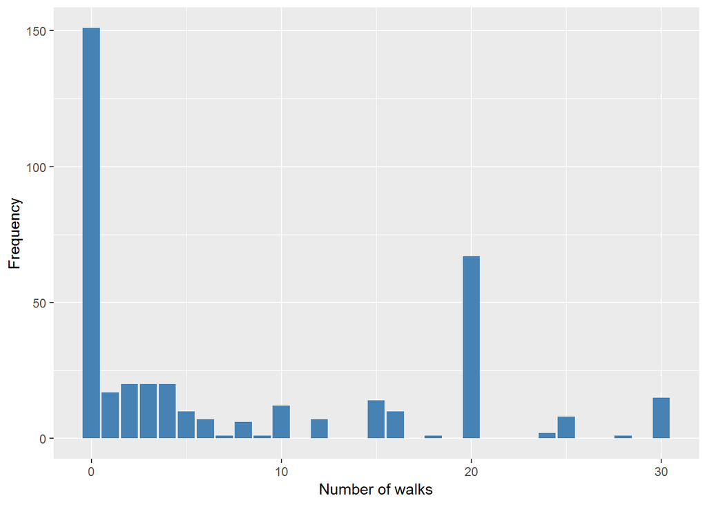

#### 2.11.2.4 Validation

|  | 0->0 | 1->1 | 2->2 | 3->3 | 4->4 | 5->5 | 6->6 | 7->7 | 8->8 | 9->9 | 10->10 | 12->12 | 15->15 | 16->16 | 18->18 | 20->20 | 24->24 | 25->25 | 28->28 | 30->30 | NA->999 |
| --- | --- | --- | --- | --- | --- | --- | --- | --- | --- | --- | --- | --- | --- | --- | --- | --- | --- | --- | --- | --- | --- |
| BeforeH | 151 | 17 | 20 | 20 | 20 | 10 | 7 | 1 | 6 | 1 | 12 | 7 | 14 | 10 | 1 | 67 | 2 | 8 | 1 | 15 | 875 |
| AfterH | 151 | 17 | 20 | 20 | 20 | 10 | 7 | 1 | 6 | 1 | 12 | 7 | 14 | 10 | 1 | 67 | 2 | 8 | 1 | 15 | 875 |

## 2.12 Summary of descriptive statistics of the harmonised variable accross populations and waves

Number of walks

| n_walks | Cuba w1 | India w1 | Urban China w1 | Rural China w1 | Dominican Republic w1 | Venezuela w1 | Urban Peru w1 | Rural Peru w1 | Urban Mexico w1 | Rural Mexico w1 | Puerto Rico w1 |
| --- | --- | --- | --- | --- | --- | --- | --- | --- | --- | --- | --- |
| Min. | 0 | 0 | 0 | 0 | 0 | 0 | 0 | 0 | 0 | 0 | 0 |
| 1st Qu. | 0 | 1 | 10 | 0 | 1 | 2 | 0 | 0 | 0 | 0 | 0 |
| Median | 5 | 2 | 25 | 5 | 6 | 3 | 4 | 3 | 3 | 5 | 0 |
| Mean | 11.41 | 4.788 | 19.68 | 9.281 | 13.2 | 9.056 | 11.5 | 6.886 | 7.702 | 10.5 | 5.068 |
| 3rd Qu. | 29 | 6 | 30 | 20 | 30 | 15 | 30 | 5 | 12 | 20 | 5 |
| Max. | 60 | 40 | 31 | 30 | 40 | 35 | 31 | 30 | 38 | 30 | 30 |
| No-missings | 2759 | 1949 | 1143 | 993 | 1634 | 1651 | 1281 | 545 | 984 | 979 | 2001 |
| 991 | 0 | 0 | 0 | 0 | 0 | 0 | 0 | 0 | 0 | 0 | 0 |
| 992 | 0 | 0 | 0 | 0 | 0 | 0 | 0 | 0 | 0 | 0 | 0 |
| 993 | 0 | 0 | 0 | 0 | 0 | 0 | 0 | 0 | 0 | 0 | 0 |
| 994 | 0 | 0 | 0 | 0 | 0 | 0 | 0 | 0 | 0 | 0 | 0 |
| 995 | 0 | 0 | 0 | 0 | 0 | 0 | 0 | 0 | 0 | 0 | 0 |
| 996 | 0 | 0 | 0 | 0 | 0 | 0 | 0 | 0 | 0 | 0 | 0 |
| 997 | 0 | 0 | 0 | 0 | 0 | 0 | 0 | 0 | 0 | 0 | 0 |
| 998 | 0 | 0 | 0 | 0 | 0 | 0 | 0 | 0 | 0 | 0 | 0 |
| 999 | 54 | 55 | 17 | 9 | 377 | 314 | 100 | 7 | 19 | 21 | 8 |
| NA | 0 | 0 | 0 | 0 | 0 | 0 | 0 | 0 | 0 | 0 | 0 |
| sample size | 2813 | 2004 | 1160 | 1002 | 2011 | 1965 | 1381 | 552 | 1003 | 1000 | 2009 |

Number of walks

| n_walks | Cuba w2 | Urban China w2 | Rural China w2 | Dominican Republic w2 | Venezuela w2 | Urban Peru w2 | Rural Peru w2 | Urban Mexico w2 | Rural Mexico w2 | Puerto Rico w2 |
| --- | --- | --- | --- | --- | --- | --- | --- | --- | --- | --- |
| Min. | 0 | 0 | 0 | 0 | 0 | 0 | 0 | 0 | 0 | 0 |
| 1st Qu. | 2 | 15 | 5 | 3 | 5 | 3 | 4 | 4 | 4 | 0 |
| Median | 8 | 20 | 15 | 8 | 15 | 8 | 7 | 8 | 20 | 3 |
| Mean | 13.01 | 20.19 | 14.74 | 13.06 | 14.05 | 12.37 | 12.91 | 12.31 | 17.83 | 7.721 |
| 3rd Qu. | 30 | 30 | 23 | 28 | 20 | 20 | 30 | 20 | 30 | 16 |
| Max. | 80 | 40 | 30 | 40 | 40 | 30 | 30 | 120 | 40 | 30 |
| No-missings | 1250 | 600 | 593 | 636 | 807 | 447 | 149 | 468 | 458 | 390 |
| 991 | 0 | 0 | 0 | 0 | 0 | 0 | 0 | 0 | 0 | 0 |
| 992 | 0 | 0 | 0 | 0 | 0 | 0 | 0 | 0 | 0 | 0 |
| 993 | 0 | 0 | 0 | 0 | 0 | 0 | 0 | 0 | 0 | 0 |
| 994 | 0 | 0 | 0 | 0 | 0 | 0 | 0 | 0 | 0 | 0 |
| 995 | 0 | 0 | 0 | 0 | 0 | 0 | 0 | 0 | 0 | 0 |
| 996 | 0 | 0 | 0 | 0 | 0 | 0 | 0 | 0 | 0 | 0 |
| 997 | 0 | 0 | 0 | 0 | 0 | 0 | 0 | 0 | 0 | 0 |
| 998 | 0 | 0 | 0 | 0 | 0 | 0 | 0 | 0 | 0 | 0 |
| 999 | 757 | 141 | 118 | 561 | 450 | 443 | 272 | 281 | 255 | 875 |
| NA | 0 | 0 | 0 | 0 | 0 | 0 | 0 | 0 | 0 | 0 |
| sample size | 2007 | 741 | 711 | 1197 | 1257 | 890 | 421 | 749 | 713 | 1265 |

# 3 Quality estimation